# Load Packages

# Correlation Matrix

```python
# correlation matrix
corr = migration_filtered.corr()
```

## Net Migration Correlations

Relevant Variables with High Positive Correlation to Net Migration:

- Net migration_United Kingdom (1): 0.816417
- Net migration_United States: 0.745383
- Enterprises_Dublin_250+: 0.743734
- Enterprises_Ireland_250+: 0.742993
- Net migration_EU14 excl Irl (UK & Ireland): 0.708039
- Trade Volume Index Imports (Base 2010): 0.585542
- General Surplus/Deficit (Million Euros): 0.558702
- Trade Volume Index Exports (Base 2010): 0.550030
- Housing_CPI: 0.536711

Relevant Variables with High Negative Correlation to Net Migration:

- Unemployment rate_Ireland_Women_Native-born: -0.882113
- Unemployment rate_Ireland_Total_Native-born: -0.876087
- Unemployment rate_Ireland_Total_Foreign-born: -0.857488
- Unemployment rate_Ireland_Women_Foreign-born: -0.851646
- Avg Unemployment Natives outside Ireland: -0.806525
- Ireland_Tax Single 100% wo Child: -0.539639
- Ireland_Tax Married 100% w 2 Children: -0.501628
- South Asia Percentage Change: -0.476842

```python
# correlation in descending order
correlations = pd.DataFrame(corr['Migration Percentage of Population'].sort_values(ascending=False))

correlations.head(n=46)
```

|  | Migration Percentage of Population |
| --- | --- |
| Migration Percentage of Population | 1.000000 |
| Net migration_All countries | 0.993911 |
| Ireland Percentage Change | 0.930078 |
| Net migration 25-44 years | 0.925730 |
| Immigrant Percentage of Population | 0.879714 |
| Net migration_EU15 to EU27 (accession countries joined post 2004) | 0.853152 |
| Net migration 15-24 years | 0.833424 |
| Net migration_United Kingdom (1) | 0.816417 |
| Immigrants_All countries | 0.808861 |
| Immigrants_EU15 to EU27 (accession countries joined post 2004) | 0.790360 |
| Immigrants 25-44 years | 0.784213 |
| Net migration_United States | 0.745383 |
| Enterprises_Dublin_250+ | 0.743734 |
| Enterprises_Ireland_250+ | 0.742993 |
| Net migration_EU14 excl Irl (UK & Ireland) | 0.708039 |
| Immigrants 15-24 years | 0.706254 |
| Immigrants_EU14 excl Irl (UK & Ireland) | 0.691569 |
| Enterprises_Ireland | 0.677912 |
| Immigrants_Other countries (23) | 0.660414 |
| Net migration_Other countries (23) | 0.631170 |
| Trade Volume Index Imports (Base 2010) | 0.585542 |
| Immigrants_United States | 0.574212 |
| General Surplus/Deficit (Million Euros) | 0.558702 |
| Immigrants_United Kingdom (1) | 0.557551 |
| Trade Volume Index Exports (Base 2010) | 0.550030 |
| Housing_CPI | 0.536711 |
| Year | 0.517932 |
| Enterprises_Dublin | 0.486631 |
| Population Ireland | 0.486083 |
| Food_Drinks_CPI | 0.407512 |
| Net Acquisition Financial Assets (Million Euros) | 0.405012 |
| United Kingdom_Tax Single 100% wo Child | 0.395008 |
| Trade Price Index Imports (Base 2010) | 0.371666 |
| Trade Price Index Exports (Base 2010) | 0.351542 |
| United Kingdom_Tax Married 100% w 2 Children | 0.334938 |
| Direct Investment Flows Abroad_United States | 0.302492 |
| Emigrants_Other countries (23) | 0.293962 |
| Direct Investment Flows in Ireland_Asia (6) | 0.291088 |
| EU in OECD_Tax Single 100% wo Child | 0.245895 |
| EU in OECD_Tax Married 100% w 2 Children | 0.193776 |
| Participation rate_Ireland_Women_Foreign-born | 0.184943 |
| GDP Growth (annual %) | 0.155290 |
| Avg Participation Natives outside Ireland | 0.101992 |
| Crisis Indicator | 0.081362 |
| Inflation Consumer Prices (Annual %) | 0.079756 |
| UK Percentage Change | 0.017038 |

```python
correlations.tail(n=38)
```

|  | Migration Percentage of Population |
| --- | --- |
| Inflation GDP Deflator (Annual %) | -0.010331 |
| General_CPI | -0.014910 |
| Participation rate_Ireland_Women_Native-born | -0.030924 |
| General Expenditure (Million Euros) | -0.067480 |
| Emigrants_EU14 excl Irl (UK & Ireland) | -0.070600 |
| Direct Investment Flows Abroad_Asia (6) | -0.071185 |
| Direct Investment Flows in Ireland_All countries and international organisations | -0.075173 |
| Participation rate_United Kingdom_Women_Native-born | -0.163657 |
| Direct Investment Flows in Ireland_EU28 | -0.191966 |
| Participation rate_United Kingdom_Women_Foreign-born | -0.198743 |
| United States_Tax Married 100% w 2 Children | -0.226818 |
| Emigrants 25-44 years | -0.236133 |
| Direct Investment Flows in Ireland_United States | -0.250618 |
| Ireland 10Y Bond Yield | -0.281153 |
| Direct Investment Flows Abroad_All countries and international organisations | -0.298302 |
| European Union Percentage Change | -0.315377 |
| Unemployment rate_United Kingdom_Total_Foreign-born | -0.368663 |
| United States_Tax Single 100% wo Child | -0.387372 |
| East Asia & Pacific Percentage Change | -0.409253 |
| Direct Investment Flows Abroad_EU28 | -0.454717 |
| Unemployment rate_United Kingdom_Women_Foreign-born | -0.455927 |
| Emigrants_All countries | -0.473020 |
| South Asia Percentage Change | -0.476842 |
| Emigrants_EU15 to EU27 (accession countries joined post 2004) | -0.483605 |
| Ireland_Tax Married 100% w 2 Children | -0.501628 |
| Ireland_Tax Single 100% wo Child | -0.539639 |
| Emigrants_United States | -0.619701 |
| Avg Unemployment Native Women outside Ireland | -0.625318 |
| Unemployment rate_United Kingdom_Total_Native-born | -0.673107 |
| Emigrant Percentage of Population | -0.679074 |
| Unemployment rate_United Kingdom_Women_Native-born | -0.683280 |
| Emigrants_United Kingdom (1) | -0.768084 |
| Emigrants 15-24 years | -0.791345 |
| Avg Unemployment Natives outside Ireland | -0.806525 |
| Unemployment rate_Ireland_Women_Foreign-born | -0.851646 |
| Unemployment rate_Ireland_Total_Foreign-born | -0.857488 |
| Unemployment rate_Ireland_Total_Native-born | -0.876087 |
| Unemployment rate_Ireland_Women_Native-born | -0.882113 |

## Immigrants Correlations

```python
# correlation in descending order
correlations_immigrants = pd.DataFrame(corr['Immigrant Percentage of Population'].sort_values(ascending=False))

correlations_immigrants.head(n=46)
```

|  | Immigrant Percentage of Population |
| --- | --- |
| Immigrant Percentage of Population | 1.000000 |
| Immigrants_All countries | 0.978030 |
| Immigrants 25-44 years | 0.927220 |
| Net migration 15-24 years | 0.907842 |
| Net migration_All countries | 0.896241 |
| Immigrants 15-24 years | 0.890711 |
| Net migration_EU15 to EU27 (accession countries joined post 2004) | 0.884466 |
| Ireland Percentage Change | 0.880559 |
| Migration Percentage of Population | 0.879714 |
| Immigrants_EU15 to EU27 (accession countries joined post 2004) | 0.867923 |
| Immigrants_EU14 excl Irl (UK & Ireland) | 0.821235 |
| Net migration 25-44 years | 0.759896 |
| Immigrants_Other countries (23) | 0.743924 |
| Trade Volume Index Imports (Base 2010) | 0.683489 |
| Net migration_EU14 excl Irl (UK & Ireland) | 0.628197 |
| Enterprises_Ireland_250+ | 0.627659 |
| Enterprises_Dublin_250+ | 0.619164 |
| Trade Volume Index Exports (Base 2010) | 0.618212 |
| Emigrants_Other countries (23) | 0.615057 |
| Net migration_Other countries (23) | 0.611772 |
| Year | 0.601661 |
| Net migration_United States | 0.598775 |
| Population Ireland | 0.586393 |
| Net migration_United Kingdom (1) | 0.570835 |
| Enterprises_Ireland | 0.537164 |
| Housing_CPI | 0.525099 |
| UK Percentage Change | 0.457054 |
| Participation rate_Ireland_Women_Foreign-born | 0.412193 |
| Immigrants_United States | 0.386838 |
| Immigrants_United Kingdom (1) | 0.351280 |
| Enterprises_Dublin | 0.345807 |
| General Expenditure (Million Euros) | 0.313763 |
| Net Acquisition Financial Assets (Million Euros) | 0.308710 |
| General Surplus/Deficit (Million Euros) | 0.289513 |
| Direct Investment Flows Abroad_United States | 0.271239 |
| Food_Drinks_CPI | 0.214569 |
| Direct Investment Flows in Ireland_Asia (6) | 0.209762 |
| Participation rate_Ireland_Women_Native-born | 0.206430 |
| Emigrants 25-44 years | 0.195532 |
| Avg Participation Natives outside Ireland | 0.191279 |
| Emigrants_EU14 excl Irl (UK & Ireland) | 0.188559 |
| United Kingdom_Tax Married 100% w 2 Children | 0.186262 |
| United Kingdom_Tax Single 100% wo Child | 0.176163 |
| General_CPI | 0.141922 |
| Inflation Consumer Prices (Annual %) | 0.140326 |
| Avg Participation Native Women outside Ireland | 0.112722 |

```python
correlations_immigrants.tail(n=38)
```

|  | Immigrant Percentage of Population |
| --- | --- |
| Participation rate_United Kingdom_Women_Foreign-born | 0.014594 |
| European Union Percentage Change | 0.012480 |
| Participation rate_United Kingdom_Women_Native-born | 0.010261 |
| EU in OECD_Tax Single 100% wo Child | 0.001406 |
| Trade Price Index Exports (Base 2010) | -0.013999 |
| Emigrants_All countries | -0.018760 |
| Direct Investment Flows in Ireland_All countries and international organisations | -0.019603 |
| GDP Growth (annual %) | -0.031227 |
| Inflation GDP Deflator (Annual %) | -0.068415 |
| EU in OECD_Tax Married 100% w 2 Children | -0.081816 |
| Direct Investment Flows Abroad_Asia (6) | -0.101254 |
| Direct Investment Flows in Ireland_EU28 | -0.111523 |
| United States_Tax Married 100% w 2 Children | -0.150508 |
| GDP per Capita Growth (Annual %) | -0.161764 |
| United States_Tax Single 100% wo Child | -0.166589 |
| Direct Investment Flows in Ireland_United States | -0.168953 |
| Unemployment rate_United Kingdom_Women_Foreign-born | -0.233016 |
| Emigrant Percentage of Population | -0.248341 |
| Ireland 10Y Bond Yield | -0.289188 |
| Direct Investment Flows Abroad_All countries and international organisations | -0.305274 |
| Unemployment rate_United Kingdom_Total_Foreign-born | -0.334818 |
| Emigrants_EU15 to EU27 (accession countries joined post 2004) | -0.340239 |
| Unemployment rate_United Kingdom_Women_Native-born | -0.414538 |
| Unemployment rate_United Kingdom_Total_Native-born | -0.426892 |
| Direct Investment Flows Abroad_EU28 | -0.456123 |
| Unemployment rate_Ireland_Women_Foreign-born | -0.526331 |
| Emigrants_United States | -0.547010 |
| Ireland_Tax Married 100% w 2 Children | -0.547448 |
| Emigrants_United Kingdom (1) | -0.554320 |
| Ireland_Tax Single 100% wo Child | -0.555659 |
| Unemployment rate_Ireland_Total_Foreign-born | -0.555664 |
| Unemployment rate_Ireland_Total_Native-born | -0.570590 |
| Unemployment rate_Ireland_Women_Native-born | -0.578274 |
| Emigrants 15-24 years | -0.607729 |
| Avg Unemployment Native Women outside Ireland | -0.611874 |
| South Asia Percentage Change | -0.619355 |
| East Asia & Pacific Percentage Change | -0.675747 |
| Avg Unemployment Natives outside Ireland | -0.712640 |

## Emigrants Correlations

```python
# correlation in descending order
correlations_emigrants = pd.DataFrame(corr['Emigrant Percentage of Population'].sort_values(ascending=False))

correlations_emigrants.head(n=46)
```

|  | Emigrant Percentage of Population |
| --- | --- |
| Emigrant Percentage of Population | 1.000000 |
| Unemployment rate_Ireland_Women_Foreign-born | 0.941131 |
| Emigrants_All countries | 0.934422 |
| Unemployment rate_Ireland_Women_Native-born | 0.928944 |
| Unemployment rate_Ireland_Total_Native-born | 0.927630 |
| Unemployment rate_Ireland_Total_Foreign-born | 0.911692 |
| Emigrants 25-44 years | 0.782527 |
| Unemployment rate_United Kingdom_Women_Native-born | 0.764117 |
| Unemployment rate_United Kingdom_Total_Native-born | 0.726843 |
| Emigrants_United Kingdom (1) | 0.709679 |
| Emigrants 15-24 years | 0.673692 |
| Emigrants_EU15 to EU27 (accession countries joined post 2004) | 0.632770 |
| Avg Unemployment Natives outside Ireland | 0.593616 |
| General Expenditure (Million Euros) | 0.584298 |
| Unemployment rate_United Kingdom_Women_Foreign-born | 0.570214 |
| United States_Tax Single 100% wo Child | 0.530333 |
| Emigrants_EU14 excl Irl (UK & Ireland) | 0.434891 |
| Emigrants_United States | 0.418559 |
| Participation rate_United Kingdom_Women_Foreign-born | 0.411110 |
| Direct Investment Flows Abroad_EU28 | 0.409857 |
| Avg Unemployment Native Women outside Ireland | 0.377644 |
| Emigrants_Other countries (23) | 0.350182 |
| Participation rate_Ireland_Women_Native-born | 0.348018 |
| Participation rate_United Kingdom_Women_Native-born | 0.336525 |
| Direct Investment Flows in Ireland_United States | 0.307138 |
| UK Percentage Change | 0.289977 |
| Ireland_Tax Single 100% wo Child | 0.288676 |
| Direct Investment Flows Abroad_All countries and international organisations | 0.263121 |
| Unemployment rate_United Kingdom_Total_Foreign-born | 0.257043 |
| Direct Investment Flows in Ireland_EU28 | 0.252697 |
| Population Ireland | 0.241877 |
| United States_Tax Married 100% w 2 Children | 0.237039 |
| Ireland_Tax Married 100% w 2 Children | 0.225391 |
| Participation rate_Ireland_Women_Foreign-born | 0.209625 |
| Trade Price Index Exports (Base 2010) | 0.187694 |
| Ireland 10Y Bond Yield | 0.141266 |
| Crisis Indicator | 0.131270 |
| Year | 0.126034 |
| Avg Participation Native Women outside Ireland | 0.125011 |
| Direct Investment Flows in Ireland_All countries and international organisations | 0.122920 |
| East Asia & Pacific Percentage Change | 0.090411 |
| Avg Participation Natives outside Ireland | 0.066390 |
| Direct Investment Flows Abroad_Asia (6) | 0.038394 |
| Trade Volume Index Exports (Base 2010) | -0.063906 |
| Immigrants 15-24 years | -0.064042 |
| Trade Volume Index Imports (Base 2010) | -0.066103 |

```python
correlations_emigrants.tail(n=38)
```

|  | Emigrant Percentage of Population |
| --- | --- |
| Immigrants_All countries | -0.137949 |
| Immigrants_EU14 excl Irl (UK & Ireland) | -0.141419 |
| Immigrants 25-44 years | -0.166125 |
| South Asia Percentage Change | -0.192613 |
| Immigrants_Other countries (23) | -0.196791 |
| GDP Growth (annual %) | -0.197158 |
| Immigrant Percentage of Population | -0.248341 |
| Housing_CPI | -0.271331 |
| Trade Price Index Imports (Base 2010) | -0.274490 |
| Direct Investment Flows Abroad_United States | -0.302718 |
| Net Acquisition Financial Assets (Million Euros) | -0.308037 |
| Inflation GDP Deflator (Annual %) | -0.331692 |
| Net migration_Other countries (23) | -0.341045 |
| Direct Investment Flows in Ireland_Asia (6) | -0.344586 |
| Inflation Consumer Prices (Annual %) | -0.350859 |
| General_CPI | -0.351229 |
| United Kingdom_Tax Married 100% w 2 Children | -0.400353 |
| Net migration 15-24 years | -0.424431 |
| Food_Drinks_CPI | -0.460536 |
| Net migration_EU14 excl Irl (UK & Ireland) | -0.472935 |
| EU in OECD_Tax Single 100% wo Child | -0.480608 |
| Immigrants_EU15 to EU27 (accession countries joined post 2004) | -0.486499 |
| EU in OECD_Tax Married 100% w 2 Children | -0.494555 |
| United Kingdom_Tax Single 100% wo Child | -0.532131 |
| Immigrants_United States | -0.572041 |
| Ireland Percentage Change | -0.587549 |
| Immigrants_United Kingdom (1) | -0.592630 |
| Net migration_United States | -0.594272 |
| Net migration_EU15 to EU27 (accession countries joined post 2004) | -0.617184 |
| General Surplus/Deficit (Million Euros) | -0.622934 |
| Enterprises_Dublin | -0.639470 |
| Net migration_All countries | -0.641053 |
| Migration Percentage of Population | -0.679074 |
| Net migration_United Kingdom (1) | -0.782187 |
| Enterprises_Ireland | -0.810037 |
| Enterprises_Ireland_250+ | -0.829885 |
| Net migration 25-44 years | -0.837233 |
| Enterprises_Dublin_250+ | -0.844332 |

```python
'Emigrant Percentage of Population', 'Immigrant Percentage of Population'
```

```
('Emigrant Percentage of Population', 'Immigrant Percentage of Population')
```

## General Correlation Matrix

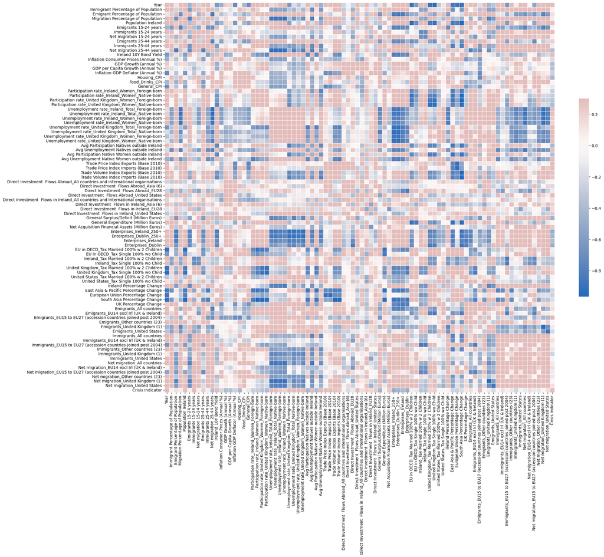

```python
# Generate a mask for the upper triangle
mask = np.triu(np.ones_like(corr, dtype=bool))

# Set up the matplotlib figure
f, ax = plt.subplots(figsize=(22, 18))


# Draw the heatmap with the mask and correct aspect ratio
sns.heatmap(corr, cmap='vlag', vmax=.3, center=0,
            square=True, linewidths=.5, cbar_kws={"shrink": .5})

plt.show()
```

# Shift Variables to T-1 and Correlations

## Shift Variables so T-1

```python
# shift rows up by one exept for column 1 and 2
migration_t1 = migration_filtered.copy()
migration_t1['Year'] = migration_filtered['Year'].shift(-1)
migration_t1['T-1 Migration Percentage of Population'] = migration_filtered['Migration Percentage of Population']
migration_t1['T-1 Emigrant Percentage of Population'] = migration_filtered['Emigrant Percentage of Population']
migration_t1['T-1 Immigrant Percentage of Population'] = migration_filtered['Immigrant Percentage of Population']
migration_t1['Migration Percentage of Population'] = migration_filtered['Migration Percentage of Population'].shift(-1)
migration_t1['Emigrant Percentage of Population'] = migration_filtered['Emigrant Percentage of Population'].shift(-1)
migration_t1['Immigrant Percentage of Population'] = migration_filtered['Immigrant Percentage of Population'].shift(-1)
migration_t1.tail()
```

|  | Year | Immigrant Percentage of Population | Emigrant Percentage of Population | Migration Percentage of Population | Population Ireland | Emigrants 15-24 years | Immigrants 15-24 years | Net migration 15-24 years | Emigrants 25-44 years | Immigrants 25-44 years | ... | Net migration_All countries | Net migration_EU14 excl Irl (UK & Ireland) | Net migration_EU15 to EU27 (accession countries joined post 2004) | Net migration_Other countries (23) | Net migration_United Kingdom (1) | Net migration_United States | Crisis Indicator | T-1 Migration Percentage of Population | T-1 Emigrant Percentage of Population | T-1 Immigrant Percentage of Population |
| --- | --- | --- | --- | --- | --- | --- | --- | --- | --- | --- | --- | --- | --- | --- | --- | --- | --- | --- | --- | --- | --- |
| 69 | 2021.0 | 1.472235 | 1.039108 | 0.433127 | 4985382.0 | 10266.666667 | 14666.666667 | 4433.333333 | 17333.333333 | 34000.000000 | ... | 44700.0 | 4800.0 | 1300.0 | 27700.0 | 7900.0 | 700.0 | 2 | 0.896621 | 1.020985 | 1.917606 |
| 70 | 2022.0 | 2.102524 | 1.094171 | 1.008354 | 5033164.0 | 12733.333333 | 9133.333333 | -3566.666667 | 13200.000000 | 26233.333333 | ... | 21800.0 | -3200.0 | 4300.0 | 5900.0 | 4100.0 | 3100.0 | 1 | 0.433127 | 1.039108 | 1.472235 |
| 71 | 2023.0 | NaN | NaN | NaN | 5127170.0 | 14033.333333 | 13933.333333 | -100.000000 | 14366.666667 | 35833.333333 | ... | 51700.0 | -4700.0 | 11800.0 | 49800.0 | -600.0 | -2000.0 | 0 | 1.008354 | 1.094171 | 2.102524 |
| 72 | 2024.0 | NaN | NaN | NaN | NaN | NaN | NaN | NaN | NaN | NaN | ... | 77700.0 | 3800.0 | 100.0 | 64100.0 | 3800.0 | 1000.0 | 0 | NaN | NaN | NaN |
| 73 | NaN | NaN | NaN | NaN | NaN | NaN | NaN | NaN | NaN | NaN | ... | NaN | NaN | NaN | NaN | NaN | NaN | 0 | NaN | NaN | NaN |

5 rows × 89 columns

```python
# correlation matrix
corr2 = migration_t1.corr()
```

## Net Migration Correlation with Last Year (Variables)

Relevant Variables T-1 with High Positive Correlation to Net Migration:

- T-1 Net migration 25-44 years: 0.899971
- T-1 Enterprises_Ireland_250+: 0.871235
- T-1 Migration Percentage of Population: 0.864008
- T-1 Enterprises_Dublin_250+: 0.832709
- T-1 Net migration_All countries: 0.831461
- T-1 Enterprises_Ireland: 0.751671
- T-1 Enterprises_Dublin: 0.749613
- T-1 General Surplus/Deficit (Million Euros): 0.728100
- T-1 Net migration_United Kingdom (1): 0.727295
- T-1 Net migration_United States: 0.703031
- T-1 Net migration_EU15 to EU27: 0.689262
- T-1 Trade Volume Index Imports (Base 2010): 0.588912
- T-1 Housing_CPI: 0.555748
- T-1 Trade Volume Index Exports (Base 2010): 0.551332

Relevant Variables T-1 with High Negative Correlation to Net Migration:

- T-1 Unemployment rate_Ireland_Total_Foreign-born: -0.831090
- T-1 Unemployment rate_Ireland_Total_Native-born: -0.829627
- T-1 Emigrants 15-24 years: -0.758266
- T-1 Emigrants_EU15 to EU27: -0.746686
- T-1 Avg Unemployment Natives outside Ireland: -0.615877
- T-1 South Asia Percentage Change: -0.456843

```python
# correlation in descending order
correlations2 = pd.DataFrame(corr2['Migration Percentage of Population'].sort_values(ascending=False))

correlations2.head(n=46)
```

|  | Migration Percentage of Population |
| --- | --- |
| Migration Percentage of Population | 1.000000 |
| Net migration 25-44 years | 0.899971 |
| Immigrant Percentage of Population | 0.879714 |
| Enterprises_Ireland_250+ | 0.871235 |
| T-1 Migration Percentage of Population | 0.864008 |
| Enterprises_Dublin_250+ | 0.832709 |
| Net migration_All countries | 0.831461 |
| Ireland Percentage Change | 0.830123 |
| Enterprises_Ireland | 0.751671 |
| Enterprises_Dublin | 0.749613 |
| General Surplus/Deficit (Million Euros) | 0.728100 |
| Net migration_United Kingdom (1) | 0.727295 |
| Immigrants 25-44 years | 0.711074 |
| Net migration_United States | 0.703031 |
| T-1 Immigrant Percentage of Population | 0.691418 |
| Net migration_EU15 to EU27 (accession countries joined post 2004) | 0.689262 |
| Immigrants_Other countries (23) | 0.629563 |
| Immigrants_All countries | 0.625844 |
| Immigrants_United Kingdom (1) | 0.610853 |
| Net migration_Other countries (23) | 0.596489 |
| Trade Volume Index Imports (Base 2010) | 0.588912 |
| Net migration_EU14 excl Irl (UK & Ireland) | 0.586364 |
| Immigrants_United States | 0.584143 |
| Housing_CPI | 0.555748 |
| Immigrants_EU14 excl Irl (UK & Ireland) | 0.555514 |
| Trade Volume Index Exports (Base 2010) | 0.551332 |
| Immigrants_EU15 to EU27 (accession countries joined post 2004) | 0.534253 |
| Year | 0.517932 |
| Net migration 15-24 years | 0.466069 |
| Population Ireland | 0.433378 |
| Immigrants 15-24 years | 0.395700 |
| EU in OECD_Tax Single 100% wo Child | 0.384603 |
| Trade Price Index Imports (Base 2010) | 0.372811 |
| GDP Growth (annual %) | 0.348799 |
| United Kingdom_Tax Single 100% wo Child | 0.347765 |
| Trade Price Index Exports (Base 2010) | 0.346298 |
| Emigrants_Other countries (23) | 0.326187 |
| EU in OECD_Tax Married 100% w 2 Children | 0.284029 |
| United Kingdom_Tax Married 100% w 2 Children | 0.250371 |
| Net Acquisition Financial Assets (Million Euros) | 0.229983 |
| GDP per Capita Growth (Annual %) | 0.223195 |
| Food_Drinks_CPI | 0.213800 |
| Avg Participation Natives outside Ireland | 0.139205 |
| Direct Investment Flows Abroad_Asia (6) | 0.122440 |
| UK Percentage Change | 0.066831 |
| Avg Participation Native Women outside Ireland | 0.055421 |

```python
correlations2.tail(n=41)
```

|  | Migration Percentage of Population |
| --- | --- |
| Participation rate_Ireland_Women_Foreign-born | -0.003797 |
| Inflation GDP Deflator (Annual %) | -0.025069 |
| Direct Investment Flows Abroad_United States | -0.027505 |
| Emigrants_EU14 excl Irl (UK & Ireland) | -0.056810 |
| Crisis Indicator | -0.062161 |
| Participation rate_United Kingdom_Women_Native-born | -0.067059 |
| Direct Investment Flows Abroad_All countries and international organisations | -0.076445 |
| Direct Investment Flows in Ireland_All countries and international organisations | -0.082476 |
| Participation rate_Ireland_Women_Native-born | -0.100330 |
| General_CPI | -0.108534 |
| Direct Investment Flows Abroad_EU28 | -0.162028 |
| Participation rate_United Kingdom_Women_Foreign-born | -0.167071 |
| General Expenditure (Million Euros) | -0.230711 |
| United States_Tax Married 100% w 2 Children | -0.240352 |
| Ireland_Tax Married 100% w 2 Children | -0.241189 |
| Ireland_Tax Single 100% wo Child | -0.259880 |
| Direct Investment Flows in Ireland_EU28 | -0.267665 |
| European Union Percentage Change | -0.281849 |
| Emigrants 25-44 years | -0.296454 |
| United States_Tax Single 100% wo Child | -0.340488 |
| Ireland 10Y Bond Yield | -0.371160 |
| Unemployment rate_United Kingdom_Total_Foreign-born | -0.395826 |
| Direct Investment Flows in Ireland_United States | -0.395854 |
| East Asia & Pacific Percentage Change | -0.417350 |
| Avg Unemployment Native Women outside Ireland | -0.429748 |
| South Asia Percentage Change | -0.456843 |
| Unemployment rate_United Kingdom_Women_Foreign-born | -0.486334 |
| Emigrants_All countries | -0.486747 |
| Emigrants_United States | -0.558234 |
| Avg Unemployment Natives outside Ireland | -0.615877 |
| Emigrants_United Kingdom (1) | -0.637540 |
| T-1 Emigrant Percentage of Population | -0.654860 |
| Emigrant Percentage of Population | -0.679074 |
| Emigrants_EU15 to EU27 (accession countries joined post 2004) | -0.746686 |
| Emigrants 15-24 years | -0.758266 |
| Unemployment rate_United Kingdom_Women_Native-born | -0.775837 |
| Unemployment rate_Ireland_Women_Native-born | -0.779446 |
| Unemployment rate_United Kingdom_Total_Native-born | -0.787911 |
| Unemployment rate_Ireland_Women_Foreign-born | -0.800784 |
| Unemployment rate_Ireland_Total_Native-born | -0.829627 |
| Unemployment rate_Ireland_Total_Foreign-born | -0.831090 |

## Immigration Correlation with Last Year (Variables)

Relevant Variables T-1 with High Positive Correlation to Immigration: T-1 Immigrants 25-44 years 0.864924 T-1 Ireland Percentage Change 0.830115 T-1 Immigrant Percentage of Population 0.807488 T-1 Immigrants_All countries 0.793701 T-1 Migration Percentage of Population 0.772947 T-1 Net migration 25-44 years 0.772836 T-1 Net migration_All countries 0.762393 T-1 Net migration_EU15 to EU27 0.761231 T-1 Trade Volume Index Imports (Base 2010) 0.708616 T-1 Enterprises_Ireland_250+ 0.706107 T-1 Immigrants_Other countries (23) 0.694612 T-1 Housing_CPI 0.663880 T-1 Emigrants_Other countries (23) 0.658244 T-1 Enterprises_Dublin_250+ 0.648473 T-1 Immigrants_EU14 excl Irl (UK & Ireland) 0.647644 T-1 Trade Volume Index Exports (Base 2010) 0.637420 T-1 Immigrants_EU15 to EU27 0.616023

Relevant Variables T-1 with High Negative Correlation to Immigration: T-1 Emigrants_EU15 to EU27 -0.737311 T-1 East Asia & Pacific Percentage Change -0.679804 T-1 Emigrants 15-24 years -0.652645 T-1 South Asia Percentage Change -0.601308 T-1 Unemployment rate_Ireland_Total_Foreign-born -0.568519 T-1 Unemployment rate_Ireland_Total_Native-born -0.566518 T-1 Emigrants_United States -0.537752 T-1 Unemployment rate_Ireland_Women_Foreign-born -0.526838 T-1 Avg Unemployment Natives outside Ireland -0.521794 T-1 Emigrants_United Kingdom (1) -0.494863 T-1 Direct Investment Flows in Ireland_United States -0.365703 T-1 Unemployment rate_United Kingdom_Total_Foreign-born -0.351771 T-1 Ireland 10Y Bond Yield -0.348417 T-1 Ireland_Tax Married 100% w 2 Children -0.323235 T-1 Ireland_Tax Single 100% wo Child -0.308793 T-1 Emigrant Percentage of Population -0.303029 T-1 Direct Investment Flows Abroad_United States -0.302372 T-1 Crisis Indicator -0.253846

```python
# correlation in descending order
correlations2_immigration = pd.DataFrame(corr2['Immigrant Percentage of Population'].sort_values(ascending=False))

correlations2_immigration.head(n=55)
```

|  | Immigrant Percentage of Population |
| --- | --- |
| Immigrant Percentage of Population | 1.000000 |
| Migration Percentage of Population | 0.879714 |
| Immigrants 25-44 years | 0.864924 |
| Ireland Percentage Change | 0.830115 |
| T-1 Immigrant Percentage of Population | 0.807488 |
| Immigrants_All countries | 0.793701 |
| T-1 Migration Percentage of Population | 0.772947 |
| Net migration 25-44 years | 0.772836 |
| Net migration_All countries | 0.762393 |
| Net migration_EU15 to EU27 (accession countries joined post 2004) | 0.761231 |
| Trade Volume Index Imports (Base 2010) | 0.708616 |
| Enterprises_Ireland_250+ | 0.706107 |
| Immigrants_Other countries (23) | 0.694612 |
| Housing_CPI | 0.663880 |
| Emigrants_Other countries (23) | 0.658244 |
| Enterprises_Dublin_250+ | 0.648473 |
| Immigrants_EU14 excl Irl (UK & Ireland) | 0.647644 |
| Trade Volume Index Exports (Base 2010) | 0.637420 |
| Immigrants_EU15 to EU27 (accession countries joined post 2004) | 0.616023 |
| Year | 0.601661 |
| Net migration_United States | 0.574983 |
| Immigrants 15-24 years | 0.570509 |
| Enterprises_Dublin | 0.562633 |
| Population Ireland | 0.545759 |
| Enterprises_Ireland | 0.544811 |
| Net migration_Other countries (23) | 0.517583 |
| Net migration_United Kingdom (1) | 0.515811 |
| Net migration_EU14 excl Irl (UK & Ireland) | 0.490801 |
| UK Percentage Change | 0.487152 |
| Net migration 15-24 years | 0.481968 |
| General Surplus/Deficit (Million Euros) | 0.428652 |
| Immigrants_United States | 0.354772 |
| Immigrants_United Kingdom (1) | 0.336261 |
| Direct Investment Flows Abroad_Asia (6) | 0.324810 |
| Trade Price Index Imports (Base 2010) | 0.289983 |
| Participation rate_Ireland_Women_Foreign-born | 0.225742 |
| GDP Growth (annual %) | 0.221755 |
| United Kingdom_Tax Single 100% wo Child | 0.219263 |
| Net Acquisition Financial Assets (Million Euros) | 0.212731 |
| Avg Participation Natives outside Ireland | 0.206551 |
| United Kingdom_Tax Married 100% w 2 Children | 0.193842 |
| General Expenditure (Million Euros) | 0.186603 |
| Emigrants_EU14 excl Irl (UK & Ireland) | 0.178741 |
| EU in OECD_Tax Single 100% wo Child | 0.169883 |
| Participation rate_Ireland_Women_Native-born | 0.119925 |
| Avg Participation Native Women outside Ireland | 0.119884 |
| Direct Investment Flows Abroad_EU28 | 0.112564 |
| GDP per Capita Growth (Annual %) | 0.097410 |
| General_CPI | 0.090844 |
| Emigrants 25-44 years | 0.089925 |
| Inflation Consumer Prices (Annual %) | 0.087640 |
| Participation rate_United Kingdom_Women_Native-born | 0.079348 |
| Direct Investment Flows Abroad_All countries and international organisations | 0.078112 |
| EU in OECD_Tax Married 100% w 2 Children | 0.063307 |
| Trade Price Index Exports (Base 2010) | 0.055955 |

```python
correlations2_immigration.tail(n=32)
```

|  | Immigrant Percentage of Population |
| --- | --- |
| European Union Percentage Change | -0.028556 |
| Inflation GDP Deflator (Annual %) | -0.029737 |
| Direct Investment Flows in Ireland_Asia (6) | -0.082132 |
| Emigrants_All countries | -0.096463 |
| Direct Investment Flows in Ireland_All countries and international organisations | -0.167926 |
| United States_Tax Single 100% wo Child | -0.174840 |
| United States_Tax Married 100% w 2 Children | -0.244158 |
| Emigrant Percentage of Population | -0.248341 |
| Crisis Indicator | -0.253846 |
| Direct Investment Flows in Ireland_EU28 | -0.276987 |
| Unemployment rate_United Kingdom_Women_Foreign-born | -0.292859 |
| Direct Investment Flows Abroad_United States | -0.302372 |
| T-1 Emigrant Percentage of Population | -0.303029 |
| Ireland_Tax Single 100% wo Child | -0.308793 |
| Ireland_Tax Married 100% w 2 Children | -0.323235 |
| Ireland 10Y Bond Yield | -0.348417 |
| Unemployment rate_United Kingdom_Total_Foreign-born | -0.351771 |
| Direct Investment Flows in Ireland_United States | -0.365703 |
| Avg Unemployment Native Women outside Ireland | -0.402162 |
| Emigrants_United Kingdom (1) | -0.494863 |
| Unemployment rate_Ireland_Women_Native-born | -0.521649 |
| Avg Unemployment Natives outside Ireland | -0.521794 |
| Unemployment rate_Ireland_Women_Foreign-born | -0.526838 |
| Emigrants_United States | -0.537752 |
| Unemployment rate_United Kingdom_Women_Native-born | -0.541286 |
| Unemployment rate_Ireland_Total_Native-born | -0.566518 |
| Unemployment rate_Ireland_Total_Foreign-born | -0.568519 |
| Unemployment rate_United Kingdom_Total_Native-born | -0.577366 |
| South Asia Percentage Change | -0.601308 |
| Emigrants 15-24 years | -0.652645 |
| East Asia & Pacific Percentage Change | -0.679804 |
| Emigrants_EU15 to EU27 (accession countries joined post 2004) | -0.737311 |

## Emigration Correlation with Last Year (Variables)

Relevant Variables T-1 with High Positive Correlation to Emigration: T-1 Unemployment rate_Ireland_Total_Foreign-born 0.880413 T-1 Unemployment rate_Ireland_Total_Native-born 0.880380 T-1 Emigrant Percentage of Population 0.855247 T-1 Emigrants 25-44 years 0.723425 T-1 General Expenditure (Million Euros) 0.690095 T-1 Emigrants_EU15 to EU27 0.618663 T-1 Emigrants 15-24 years 0.542727 T-1 Emigrants_United Kingdom (1) 0.537275 T-1 Avg Unemployment Natives outside Ireland 0.509909 T-1 United States_Tax Single 100% wo Child 0.443906 T-1 Direct Investment Flows in Ireland_United States 0.419093 T-1 Direct Investment Flows Abroad_EU28 0.416764

Relevant Variables T-1 with High Negative Correlation to Emigration: T-1 Enterprises_Ireland_250+ -0.934059 T-1 Net migration 25-44 years -0.792953 T-1 General Surplus/Deficit (Million Euros) -0.745696 T-1 Immigrants_United Kingdom (1) -0.717583 T-1 Immigrants_United States -0.637296 T-1 Migration Percentage of Population -0.545372 T-1 EU in OECD_Tax Single 100% wo Child -0.539297 T-1 EU in OECD_Tax Married 100% w 2 Children -0.487056 T-1 Net migration_EU14 excl Irl (UK & Ireland) -0.440659 T-1 Net migration_Other countries (23) -0.420701 T-1 Net migration_EU15 to EU27 -0.416033 T-1 United Kingdom_Tax Single 100% wo Child -0.396004 T-1 Food_Drinks_CPI -0.388688 T-1 Inflation GDP Deflator (Annual %) -0.358196

```python
# correlation in descending order
correlations2_immigration = pd.DataFrame(corr2['Emigrant Percentage of Population'].sort_values(ascending=False))

correlations2_immigration.head(n=41)
```

|  | Emigrant Percentage of Population |
| --- | --- |
| Emigrant Percentage of Population | 1.000000 |
| Unemployment rate_Ireland_Total_Foreign-born | 0.880413 |
| Unemployment rate_Ireland_Total_Native-born | 0.880380 |
| Unemployment rate_Ireland_Women_Foreign-born | 0.878270 |
| T-1 Emigrant Percentage of Population | 0.855247 |
| Unemployment rate_Ireland_Women_Native-born | 0.842500 |
| Emigrants_All countries | 0.826387 |
| Unemployment rate_United Kingdom_Women_Native-born | 0.813200 |
| Unemployment rate_United Kingdom_Total_Native-born | 0.786654 |
| Emigrants 25-44 years | 0.723425 |
| General Expenditure (Million Euros) | 0.690095 |
| Emigrants_EU15 to EU27 (accession countries joined post 2004) | 0.618663 |
| Unemployment rate_United Kingdom_Women_Foreign-born | 0.575203 |
| Emigrants 15-24 years | 0.542727 |
| Emigrants_United Kingdom (1) | 0.537275 |
| Avg Unemployment Natives outside Ireland | 0.509909 |
| United States_Tax Single 100% wo Child | 0.443906 |
| Direct Investment Flows in Ireland_United States | 0.419093 |
| Direct Investment Flows Abroad_EU28 | 0.416764 |
| Participation rate_United Kingdom_Women_Foreign-born | 0.394338 |
| Emigrants_EU14 excl Irl (UK & Ireland) | 0.377725 |
| Participation rate_Ireland_Women_Native-born | 0.374474 |
| UK Percentage Change | 0.338957 |
| Participation rate_Ireland_Women_Foreign-born | 0.328367 |
| Emigrants_Other countries (23) | 0.326398 |
| Emigrants_United States | 0.315041 |
| Unemployment rate_United Kingdom_Total_Foreign-born | 0.307726 |
| Avg Unemployment Native Women outside Ireland | 0.301778 |
| Population Ireland | 0.279593 |
| Participation rate_United Kingdom_Women_Native-born | 0.249361 |
| Ireland 10Y Bond Yield | 0.244184 |
| Crisis Indicator | 0.235674 |
| Direct Investment Flows Abroad_All countries and international organisations | 0.223722 |
| Direct Investment Flows in Ireland_EU28 | 0.223051 |
| United States_Tax Married 100% w 2 Children | 0.142104 |
| Year | 0.126034 |
| Direct Investment Flows Abroad_Asia (6) | 0.099525 |
| Trade Price Index Exports (Base 2010) | 0.097773 |
| Ireland_Tax Single 100% wo Child | 0.090452 |
| Avg Participation Native Women outside Ireland | 0.058501 |
| Immigrants 15-24 years | 0.056952 |

```python
correlations2_immigration.tail(n=46)
```

|  | Emigrant Percentage of Population |
| --- | --- |
| Avg Participation Natives outside Ireland | 0.011334 |
| Direct Investment Flows in Ireland_All countries and international organisations | -0.011939 |
| Trade Volume Index Exports (Base 2010) | -0.039857 |
| Trade Volume Index Imports (Base 2010) | -0.044001 |
| Immigrants_All countries | -0.069989 |
| European Union Percentage Change | -0.070998 |
| Direct Investment Flows in Ireland_Asia (6) | -0.111250 |
| Net Acquisition Financial Assets (Million Euros) | -0.127752 |
| Immigrants 25-44 years | -0.133827 |
| Housing_CPI | -0.134496 |
| Immigrants_EU14 excl Irl (UK & Ireland) | -0.147037 |
| T-1 Immigrant Percentage of Population | -0.180128 |
| South Asia Percentage Change | -0.213795 |
| Immigrants_Other countries (23) | -0.224044 |
| United Kingdom_Tax Married 100% w 2 Children | -0.234373 |
| GDP per Capita Growth (Annual %) | -0.238182 |
| Immigrant Percentage of Population | -0.248341 |
| Direct Investment Flows Abroad_United States | -0.250289 |
| Immigrants_EU15 to EU27 (accession countries joined post 2004) | -0.272499 |
| Net migration 15-24 years | -0.283836 |
| GDP Growth (annual %) | -0.308314 |
| Inflation Consumer Prices (Annual %) | -0.311547 |
| General_CPI | -0.311620 |
| Trade Price Index Imports (Base 2010) | -0.330898 |
| Inflation GDP Deflator (Annual %) | -0.358196 |
| Food_Drinks_CPI | -0.388688 |
| United Kingdom_Tax Single 100% wo Child | -0.396004 |
| Net migration_EU15 to EU27 (accession countries joined post 2004) | -0.416033 |
| Net migration_Other countries (23) | -0.420701 |
| Net migration_EU14 excl Irl (UK & Ireland) | -0.440659 |
| Ireland Percentage Change | -0.454175 |
| EU in OECD_Tax Married 100% w 2 Children | -0.487056 |
| Net migration_All countries | -0.525879 |
| EU in OECD_Tax Single 100% wo Child | -0.539297 |
| T-1 Migration Percentage of Population | -0.545372 |
| Net migration_United States | -0.548065 |
| Immigrants_United States | -0.637296 |
| Migration Percentage of Population | -0.679074 |
| Net migration_United Kingdom (1) | -0.684572 |
| Immigrants_United Kingdom (1) | -0.717583 |
| General Surplus/Deficit (Million Euros) | -0.745696 |
| Net migration 25-44 years | -0.792953 |
| Enterprises_Dublin | -0.854674 |
| Enterprises_Ireland | -0.880033 |
| Enterprises_Dublin_250+ | -0.923182 |
| Enterprises_Ireland_250+ | -0.934059 |

# Shift Variables to T-2

```python
# shift rows up by one exept for column 1 and 2
migration_t2 = migration_t1.copy()
migration_t2['Year'] = migration_t1['Year'].shift(-1)
migration_t2['T-2 Migration Percentage of Population'] = migration_t1['T-1 Migration Percentage of Population']
migration_t2['T-2 Emigrant Percentage of Population'] = migration_t1['T-1 Emigrant Percentage of Population']
migration_t2['T-2 Immigrant Percentage of Population'] = migration_t1['T-1 Immigrant Percentage of Population']
migration_t2['T-1 Migration Percentage of Population'] = migration_t1['Migration Percentage of Population']
migration_t2['T-1 Emigrant Percentage of Population'] = migration_t1['Emigrant Percentage of Population']
migration_t2['T-1 Immigrant Percentage of Population'] = migration_t1['Immigrant Percentage of Population']
migration_t2['Migration Percentage of Population'] = migration_t1['Migration Percentage of Population'].shift(-1)
migration_t2['Emigrant Percentage of Population'] = migration_t1['Emigrant Percentage of Population'].shift(-1)
migration_t2['Immigrant Percentage of Population'] = migration_t1['Immigrant Percentage of Population'].shift(-1)
migration_t2.tail()
```

|  | Year | Immigrant Percentage of Population | Emigrant Percentage of Population | Migration Percentage of Population | Population Ireland | Emigrants 15-24 years | Immigrants 15-24 years | Net migration 15-24 years | Emigrants 25-44 years | Immigrants 25-44 years | ... | Net migration_Other countries (23) | Net migration_United Kingdom (1) | Net migration_United States | Crisis Indicator | T-1 Migration Percentage of Population | T-1 Emigrant Percentage of Population | T-1 Immigrant Percentage of Population | T-2 Migration Percentage of Population | T-2 Emigrant Percentage of Population | T-2 Immigrant Percentage of Population |
| --- | --- | --- | --- | --- | --- | --- | --- | --- | --- | --- | --- | --- | --- | --- | --- | --- | --- | --- | --- | --- | --- |
| 69 | 2022.0 | 2.102524 | 1.094171 | 1.008354 | 4985382.0 | 10266.666667 | 14666.666667 | 4433.333333 | 17333.333333 | 34000.000000 | ... | 27700.0 | 7900.0 | 700.0 | 2 | 0.433127 | 1.039108 | 1.472235 | 0.896621 | 1.020985 | 1.917606 |
| 70 | 2023.0 | NaN | NaN | NaN | 5033164.0 | 12733.333333 | 9133.333333 | -3566.666667 | 13200.000000 | 26233.333333 | ... | 5900.0 | 4100.0 | 3100.0 | 1 | 1.008354 | 1.094171 | 2.102524 | 0.433127 | 1.039108 | 1.472235 |
| 71 | 2024.0 | NaN | NaN | NaN | 5127170.0 | 14033.333333 | 13933.333333 | -100.000000 | 14366.666667 | 35833.333333 | ... | 49800.0 | -600.0 | -2000.0 | 0 | NaN | NaN | NaN | 1.008354 | 1.094171 | 2.102524 |
| 72 | NaN | NaN | NaN | NaN | NaN | NaN | NaN | NaN | NaN | NaN | ... | 64100.0 | 3800.0 | 1000.0 | 0 | NaN | NaN | NaN | NaN | NaN | NaN |
| 73 | NaN | NaN | NaN | NaN | NaN | NaN | NaN | NaN | NaN | NaN | ... | NaN | NaN | NaN | 0 | NaN | NaN | NaN | NaN | NaN | NaN |

5 rows × 92 columns

```python
# correlation matrix
corr3 = migration_t2.corr()
```

```python
correlations2.head(n=10)
```

|  | Migration Percentage of Population |
| --- | --- |
| Migration Percentage of Population | 1.000000 |
| Net migration 25-44 years | 0.899971 |
| Immigrant Percentage of Population | 0.879714 |
| Enterprises_Ireland_250+ | 0.871235 |
| T-1 Migration Percentage of Population | 0.864008 |
| Enterprises_Dublin_250+ | 0.832709 |
| Net migration_All countries | 0.831461 |
| Ireland Percentage Change | 0.830123 |
| Enterprises_Ireland | 0.751671 |
| Enterprises_Dublin | 0.749613 |

```python
# correlation in descending order
correlations3 = pd.DataFrame(corr3['Migration Percentage of Population'].sort_values(ascending=False))

correlations3.head(n=10)
```

|  | Migration Percentage of Population |
| --- | --- |
| Migration Percentage of Population | 1.000000 |
| Immigrant Percentage of Population | 0.879714 |
| T-1 Migration Percentage of Population | 0.864008 |
| Enterprises_Dublin | 0.849269 |
| Enterprises_Ireland_250+ | 0.717679 |
| Enterprises_Dublin_250+ | 0.694419 |
| T-1 Immigrant Percentage of Population | 0.691418 |
| Enterprises_Ireland | 0.688713 |
| General Surplus/Deficit (Million Euros) | 0.660332 |
| T-2 Migration Percentage of Population | 0.652735 |

T-2 does not create higher correlations, so therefore keep the T-1 variables

# Graphs

## Net Migration

### Net Migration Ireland and Previous Year Net migration 25-44 years

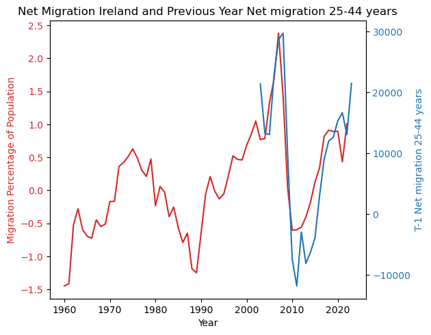

```python
fig, ax1 = plt.subplots()

color = 'tab:red'
ax1.set_xlabel('Year')
ax1.set_ylabel('Migration Percentage of Population', color=color)
ax1.plot(migration_t1['Year'], migration_t1['Migration Percentage of Population'], color=color)
ax1.tick_params(axis='y', labelcolor=color)

ax2 = ax1.twinx()  # instantiate a second axes that shares the same x-axis

color = 'tab:blue'
ax2.set_ylabel('T-1 Net migration 25-44 years', color=color)  # we already handled the x-label with ax1
ax2.plot(migration_t1['Year'], migration_t1['Net migration 25-44 years'], color=color)
ax2.tick_params(axis='y', labelcolor=color)

fig.tight_layout()  # otherwise the right y-label is slightly clipped
plt.title('Net Migration Ireland and Previous Year Net migration 25-44 years')
plt.show()
```

### Net Migration Ireland and Previous Year Enterprises_Ireland_250+

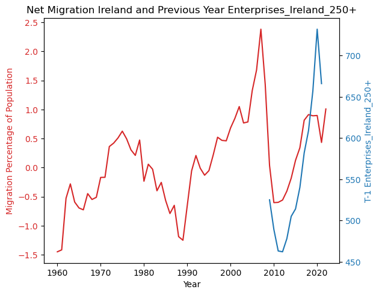

```python
fig, ax1 = plt.subplots()

color = 'tab:red'
ax1.set_xlabel('Year')
ax1.set_ylabel('Migration Percentage of Population', color=color)
ax1.plot(migration_t1['Year'], migration_t1['Migration Percentage of Population'], color=color)
ax1.tick_params(axis='y', labelcolor=color)

ax2 = ax1.twinx()  # instantiate a second axes that shares the same x-axis

color = 'tab:blue'
ax2.set_ylabel('T-1 Enterprises_Ireland_250+', color=color)  # we already handled the x-label with ax1
ax2.plot(migration_t1['Year'], migration_t1['Enterprises_Ireland_250+'], color=color)
ax2.tick_params(axis='y', labelcolor=color)

fig.tight_layout()  # otherwise the right y-label is slightly clipped
plt.title('Net Migration Ireland and Previous Year Enterprises_Ireland_250+')
plt.show()
```

### Net Migration Ireland and Previous Year Migration Percentage of Population

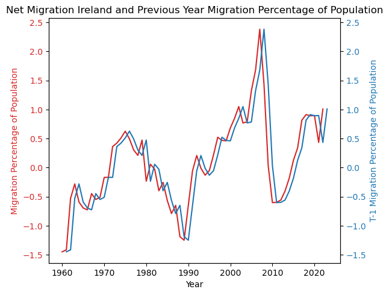

```python
fig, ax1 = plt.subplots()

color = 'tab:red'
ax1.set_xlabel('Year')
ax1.set_ylabel('Migration Percentage of Population', color=color)
ax1.plot(migration_t1['Year'], migration_t1['Migration Percentage of Population'], color=color)
ax1.tick_params(axis='y', labelcolor=color)

ax2 = ax1.twinx()  # instantiate a second axes that shares the same x-axis

color = 'tab:blue'
ax2.set_ylabel('T-1 Migration Percentage of Population', color=color)  # we already handled the x-label with ax1
ax2.plot(migration_t1['Year'], migration_t1['T-1 Migration Percentage of Population'], color=color)
ax2.tick_params(axis='y', labelcolor=color)

fig.tight_layout()  # otherwise the right y-label is slightly clipped
plt.title('Net Migration Ireland and Previous Year Migration Percentage of Population')
plt.show()
```

### Net Migration Ireland and Previous Year General Surplus/Deficit (Million Euros)

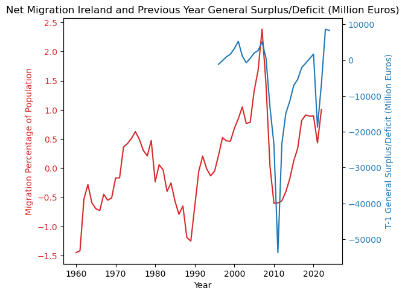

```python
fig, ax1 = plt.subplots()

color = 'tab:red'
ax1.set_xlabel('Year')
ax1.set_ylabel('Migration Percentage of Population', color=color)
ax1.plot(migration_t1['Year'], migration_t1['Migration Percentage of Population'], color=color)
ax1.tick_params(axis='y', labelcolor=color)

ax2 = ax1.twinx()  # instantiate a second axes that shares the same x-axis

color = 'tab:blue'
ax2.set_ylabel('T-1 General Surplus/Deficit (Million Euros)', color=color)  # we already handled the x-label with ax1
ax2.plot(migration_t1['Year'], migration_t1['General Surplus/Deficit (Million Euros)'], color=color)
ax2.tick_params(axis='y', labelcolor=color)

fig.tight_layout()  # otherwise the right y-label is slightly clipped
plt.title('Net Migration Ireland and Previous Year General Surplus/Deficit (Million Euros)')
plt.show()
```

### Net Migration Ireland and Previous Year Unemployment rate_Ireland_Total_Foreign-born

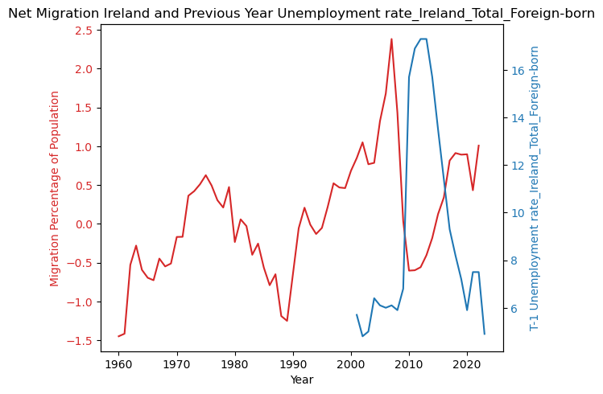

```python
fig, ax1 = plt.subplots()

color = 'tab:red'
ax1.set_xlabel('Year')
ax1.set_ylabel('Migration Percentage of Population', color=color)
ax1.plot(migration_t1['Year'], migration_t1['Migration Percentage of Population'], color=color)
ax1.tick_params(axis='y', labelcolor=color)

ax2 = ax1.twinx()  # instantiate a second axes that shares the same x-axis

color = 'tab:blue'
ax2.set_ylabel('T-1 Unemployment rate_Ireland_Total_Foreign-born', color=color)  # we already handled the x-label with ax1
ax2.plot(migration_t1['Year'], migration_t1['Unemployment rate_Ireland_Total_Foreign-born'], color=color)
ax2.tick_params(axis='y', labelcolor=color)

fig.tight_layout()  # otherwise the right y-label is slightly clipped
plt.title('Net Migration Ireland and Previous Year Unemployment rate_Ireland_Total_Foreign-born')
plt.show()
```

## Immigration

### Immigration Ireland and Previous Year Immigrants 25-44 years

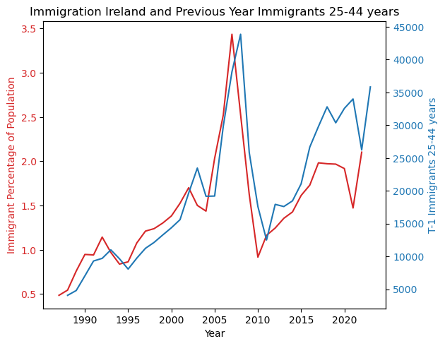

```python
fig, ax1 = plt.subplots()

color = 'tab:red'
ax1.set_xlabel('Year')
ax1.set_ylabel('Immigrant Percentage of Population', color=color)
ax1.plot(migration_t1['Year'], migration_t1['Immigrant Percentage of Population'], color=color)
ax1.tick_params(axis='y', labelcolor=color)

ax2 = ax1.twinx()  # instantiate a second axes that shares the same x-axis

color = 'tab:blue'
ax2.set_ylabel('T-1 Immigrants 25-44 years', color=color)  # we already handled the x-label with ax1
ax2.plot(migration_t1['Year'], migration_t1['Immigrants 25-44 years'], color=color)
ax2.tick_params(axis='y', labelcolor=color)

fig.tight_layout()  # otherwise the right y-label is slightly clipped
plt.title('Immigration Ireland and Previous Year Immigrants 25-44 years')
plt.show()
```

### Immigration Ireland and Previous Year Trade Volume Index Imports (Base 2010)

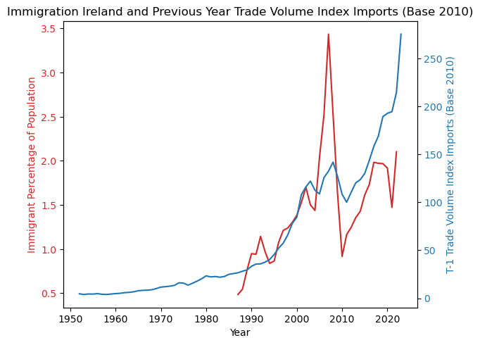

```python
fig, ax1 = plt.subplots()

color = 'tab:red'
ax1.set_xlabel('Year')
ax1.set_ylabel('Immigrant Percentage of Population', color=color)
ax1.plot(migration_t1['Year'], migration_t1['Immigrant Percentage of Population'], color=color)
ax1.tick_params(axis='y', labelcolor=color)

ax2 = ax1.twinx()  # instantiate a second axes that shares the same x-axis

color = 'tab:blue'
ax2.set_ylabel('T-1 Trade Volume Index Imports (Base 2010)', color=color)  # we already handled the x-label with ax1
ax2.plot(migration_t1['Year'], migration_t1['Trade Volume Index Imports (Base 2010)'], color=color)
ax2.tick_params(axis='y', labelcolor=color)

fig.tight_layout()  # otherwise the right y-label is slightly clipped
plt.title('Immigration Ireland and Previous Year Trade Volume Index Imports (Base 2010)')
plt.show()
```

### Immigration Ireland and Previous Year Enterprises_Ireland_250+

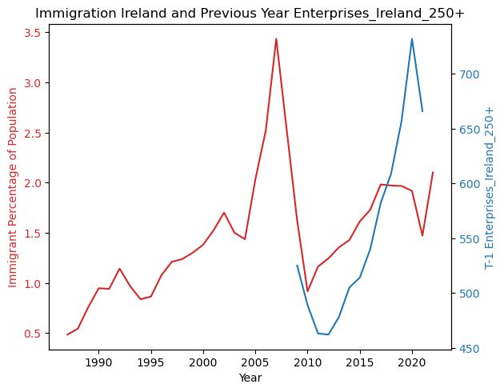

```python
fig, ax1 = plt.subplots()

color = 'tab:red'
ax1.set_xlabel('Year')
ax1.set_ylabel('Immigrant Percentage of Population', color=color)
ax1.plot(migration_t1['Year'], migration_t1['Immigrant Percentage of Population'], color=color)
ax1.tick_params(axis='y', labelcolor=color)

ax2 = ax1.twinx()  # instantiate a second axes that shares the same x-axis

color = 'tab:blue'
ax2.set_ylabel('T-1 Enterprises_Ireland_250+', color=color)  # we already handled the x-label with ax1
ax2.plot(migration_t1['Year'], migration_t1['Enterprises_Ireland_250+'], color=color)
ax2.tick_params(axis='y', labelcolor=color)

fig.tight_layout()  # otherwise the right y-label is slightly clipped
plt.title('Immigration Ireland and Previous Year Enterprises_Ireland_250+')
plt.show()
```

### Immigration Ireland and Previous Year Housing_CPI

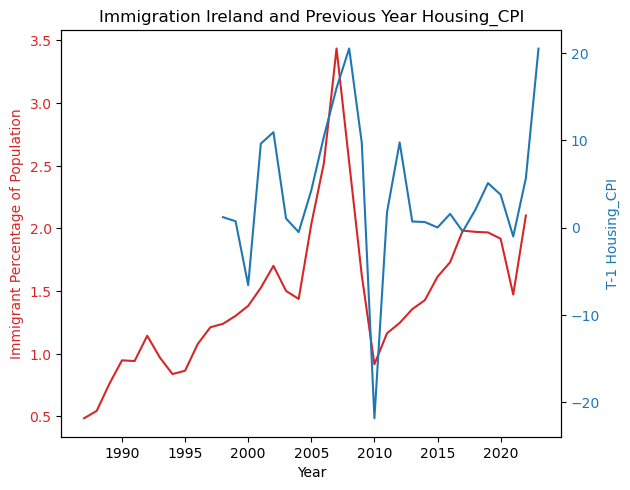

```python
fig, ax1 = plt.subplots()

color = 'tab:red'
ax1.set_xlabel('Year')
ax1.set_ylabel('Immigrant Percentage of Population', color=color)
ax1.plot(migration_t1['Year'], migration_t1['Immigrant Percentage of Population'], color=color)
ax1.tick_params(axis='y', labelcolor=color)

ax2 = ax1.twinx()  # instantiate a second axes that shares the same x-axis

color = 'tab:blue'
ax2.set_ylabel('T-1 Housing_CPI', color=color)  # we already handled the x-label with ax1
ax2.plot(migration_t1['Year'], migration_t1['Housing_CPI'], color=color)
ax2.tick_params(axis='y', labelcolor=color)

fig.tight_layout()  # otherwise the right y-label is slightly clipped
plt.title('Immigration Ireland and Previous Year Housing_CPI')
plt.show()
```

### Immigration Ireland and Previous Year Emigrants_EU15 to EU27 (accession countries joined post 2004)

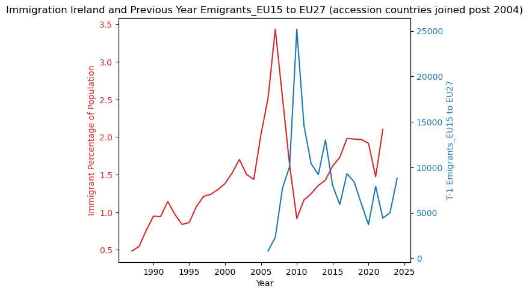

```python
fig, ax1 = plt.subplots()

color = 'tab:red'
ax1.set_xlabel('Year')
ax1.set_ylabel('Immigrant Percentage of Population', color=color)
ax1.plot(migration_t1['Year'], migration_t1['Immigrant Percentage of Population'], color=color)
ax1.tick_params(axis='y', labelcolor=color)

ax2 = ax1.twinx()  # instantiate a second axes that shares the same x-axis

color = 'tab:blue'
ax2.set_ylabel('T-1 Emigrants_EU15 to EU27', color=color)  # we already handled the x-label with ax1
ax2.plot(migration_t1['Year'], migration_t1['Emigrants_EU15 to EU27 (accession countries joined post 2004)'], color=color)
ax2.tick_params(axis='y', labelcolor=color)

fig.tight_layout()  # otherwise the right y-label is slightly clipped
plt.title('Immigration Ireland and Previous Year Emigrants_EU15 to EU27 (accession countries joined post 2004)')
plt.show()
```

### Immigration Ireland and Previous Year East Asia & Pacific Percentage Change

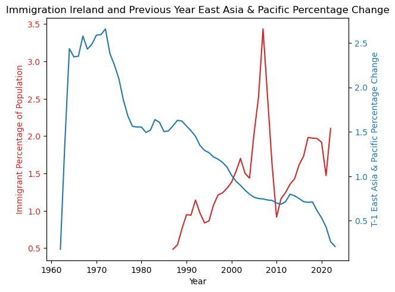

```python
fig, ax1 = plt.subplots()

color = 'tab:red'
ax1.set_xlabel('Year')
ax1.set_ylabel('Immigrant Percentage of Population', color=color)
ax1.plot(migration_t1['Year'], migration_t1['Immigrant Percentage of Population'], color=color)
ax1.tick_params(axis='y', labelcolor=color)

ax2 = ax1.twinx()  # instantiate a second axes that shares the same x-axis

color = 'tab:blue'
ax2.set_ylabel('T-1 East Asia & Pacific Percentage Change', color=color)  # we already handled the x-label with ax1
ax2.plot(migration_t1['Year'], migration_t1['East Asia & Pacific Percentage Change'], color=color)
ax2.tick_params(axis='y', labelcolor=color)

fig.tight_layout()  # otherwise the right y-label is slightly clipped
plt.title('Immigration Ireland and Previous Year East Asia & Pacific Percentage Change')
plt.show()
```

## Emigration

### Emigration from Ireland and Previous Year Unemployment in Ireland for Foreign-Born

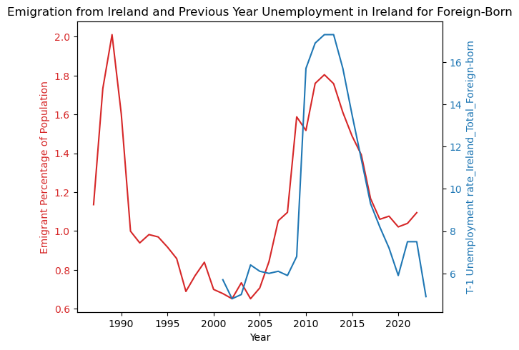

```python
fig, ax1 = plt.subplots()

color = 'tab:red'
ax1.set_xlabel('Year')
ax1.set_ylabel('Emigrant Percentage of Population', color=color)
ax1.plot(migration_t1['Year'], migration_t1['Emigrant Percentage of Population'], color=color)
ax1.tick_params(axis='y', labelcolor=color)

ax2 = ax1.twinx()  # instantiate a second axes that shares the same x-axis

color = 'tab:blue'
ax2.set_ylabel('T-1 Unemployment rate_Ireland_Total_Foreign-born', color=color)  # we already handled the x-label with ax1
ax2.plot(migration_t1['Year'], migration_t1['Unemployment rate_Ireland_Total_Foreign-born'], color=color)
ax2.tick_params(axis='y', labelcolor=color)

fig.tight_layout()  # otherwise the right y-label is slightly clipped
plt.title('Emigration from Ireland and Previous Year Unemployment in Ireland for Foreign-Born')
plt.show()
```

### Emigration from Ireland and Previous Year Emigrant Percentage of Population

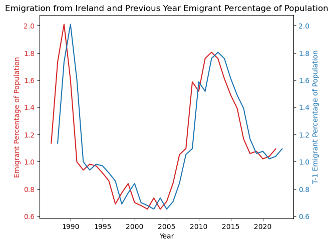

```python
fig, ax1 = plt.subplots()

color = 'tab:red'
ax1.set_xlabel('Year')
ax1.set_ylabel('Emigrant Percentage of Population', color=color)
ax1.plot(migration_t1['Year'], migration_t1['Emigrant Percentage of Population'], color=color)
ax1.tick_params(axis='y', labelcolor=color)

ax2 = ax1.twinx()  # instantiate a second axes that shares the same x-axis

color = 'tab:blue'
ax2.set_ylabel('T-1 Emigrant Percentage of Population', color=color)  # we already handled the x-label with ax1
ax2.plot(migration_t1['Year'], migration_t1['T-1 Emigrant Percentage of Population'], color=color)
ax2.tick_params(axis='y', labelcolor=color)

fig.tight_layout()  # otherwise the right y-label is slightly clipped
plt.title('Emigration from Ireland and Previous Year Emigrant Percentage of Population')
plt.show()
```

### Emigration from Ireland and Previous Year Number of Enterprises in Ireland

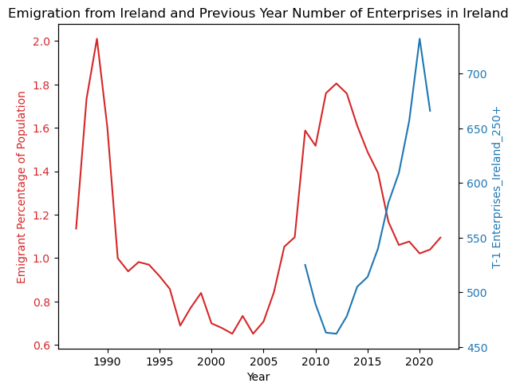

```python
fig, ax1 = plt.subplots()

color = 'tab:red'
ax1.set_xlabel('Year')
ax1.set_ylabel('Emigrant Percentage of Population', color=color)
ax1.plot(migration_t1['Year'], migration_t1['Emigrant Percentage of Population'], color=color)
ax1.tick_params(axis='y', labelcolor=color)

ax2 = ax1.twinx()  # instantiate a second axes that shares the same x-axis

color = 'tab:blue'
ax2.set_ylabel('T-1 Enterprises_Ireland_250+', color=color)  # we already handled the x-label with ax1
ax2.plot(migration_t1['Year'], migration_t1['Enterprises_Ireland_250+'], color=color)
ax2.tick_params(axis='y', labelcolor=color)

fig.tight_layout()  # otherwise the right y-label is slightly clipped
plt.title('Emigration from Ireland and Previous Year Number of Enterprises in Ireland')
plt.show()
```

# Filter Data for Net Migration

## Initial

```python
migration_t1.columns
```

```
Index(['Year', 'Immigrant Percentage of Population',
       'Emigrant Percentage of Population',
       'Migration Percentage of Population', 'Population Ireland',
       'Emigrants 15-24 years', 'Immigrants 15-24 years',
       'Net migration 15-24 years', 'Emigrants 25-44 years',
       'Immigrants 25-44 years', 'Net migration 25-44 years',
       'Ireland 10Y Bond Yield', 'Inflation Consumer Prices (Annual %)',
       'GDP Growth (annual %)', 'GDP per Capita Growth (Annual %)',
       'Inflation GDP Deflator (Annual %)', 'Housing_CPI', 'Food_Drinks_CPI',
       'General_CPI', 'Participation rate_Ireland_Women_Foreign-born',
       'Participation rate_Ireland_Women_Native-born',
       'Participation rate_United Kingdom_Women_Foreign-born',
       'Participation rate_United Kingdom_Women_Native-born',
       'Unemployment rate_Ireland_Total_Foreign-born',
       'Unemployment rate_Ireland_Total_Native-born',
       'Unemployment rate_Ireland_Women_Foreign-born',
       'Unemployment rate_Ireland_Women_Native-born',
       'Unemployment rate_United Kingdom_Total_Foreign-born',
       'Unemployment rate_United Kingdom_Total_Native-born',
       'Unemployment rate_United Kingdom_Women_Foreign-born',
       'Unemployment rate_United Kingdom_Women_Native-born',
       'Avg Participation Natives outside Ireland',
       'Avg Unemployment Natives outside Ireland',
       'Avg Participation Native Women outside Ireland',
       'Avg Unemployment Native Women outside Ireland',
       'Trade Price Index Exports (Base 2010)',
       'Trade Price Index Imports (Base 2010)',
       'Trade Volume Index Exports (Base 2010)',
       'Trade Volume Index Imports (Base 2010)',
       'Direct Investment  Flows Abroad_All countries and international organisations',
       'Direct Investment  Flows Abroad_Asia (6)',
       'Direct Investment  Flows Abroad_EU28',
       'Direct Investment  Flows Abroad_United States',
       'Direct Investment  Flows in Ireland_All countries and international organisations',
       'Direct Investment  Flows in Ireland_Asia (6)',
       'Direct Investment  Flows in Ireland_EU28',
       'Direct Investment  Flows in Ireland_United States',
       'General Surplus/Deficit (Million Euros)',
       'General Expenditure (Million Euros)',
       'Net Acquisition Financial Assets (Million Euros)',
```

[output cut: 14 more lines]

```
       'Emigrants_EU15 to EU27 (accession countries joined post 2004)',
       'Emigrants_Other countries (23)', 'Emigrants_United Kingdom (1)',
       'Emigrants_United States', 'Immigrants_All countries',
       'Immigrants_EU14 excl Irl (UK & Ireland)',
       'Immigrants_EU15 to EU27 (accession countries joined post 2004)',
       'Immigrants_Other countries (23)', 'Immigrants_United Kingdom (1)',
       'Immigrants_United States', 'Net migration_All countries',
       'Net migration_EU14 excl Irl (UK & Ireland)',
       'Net migration_EU15 to EU27 (accession countries joined post 2004)',
       'Net migration_Other countries (23)',
       'Net migration_United Kingdom (1)', 'Net migration_United States',
       'Crisis Indicator', 'T-1 Migration Percentage of Population',
       'T-1 Emigrant Percentage of Population',
       'T-1 Immigrant Percentage of Population'],
      dtype='object')
```

```python
Net_Migration = migration_t1[['Year',
                              'Migration Percentage of Population',
                              'Net migration 25-44 years',
                              'Enterprises_Ireland_250+',
                              'General Surplus/Deficit (Million Euros)',
                              'Trade Volume Index Imports (Base 2010)',
                              'Housing_CPI',
                              'Trade Volume Index Exports (Base 2010)',
                              'Unemployment rate_Ireland_Total_Foreign-born',
                              'Emigrants 15-24 years',
                              'Emigrants_EU15 to EU27 (accession countries joined post 2004)',
                              'South Asia Percentage Change',
                              'T-1 Migration Percentage of Population',
                              'Crisis Indicator'
]]
```

```python
# rename columns Net_Migration
Net_Migration.rename(columns={
    'Year': 'Year',
    'Net migration 25-44 years': 'T-1 Net migration 25-44 years',
    'Enterprises_Ireland_250+': 'T-1 Enterprises_Ireland_250+',
    'General Surplus/Deficit (Million Euros)': 'T-1 General Surplus/Deficit (Million Euros)',
    'Trade Volume Index Imports (Base 2010)': 'T-1 Trade Volume Index Imports (Base 2010)',
    'Housing_CPI': 'T-1 Housing_CPI',
    'Trade Volume Index Exports (Base 2010)': 'T-1 Trade Volume Index Exports (Base 2010)',
    'Unemployment rate_Ireland_Total_Foreign-born': 'T-1 Unemployment rate_Ireland_Total_Foreign-born',
    'Emigrants 15-24 years': 'T-1 Emigrants 15-24 years',
    'Emigrants_EU15 to EU27 (accession countries joined post 2004)': 'T-1 Emigrants_EU15 to EU27',
    'South Asia Percentage Change': 'T-1 South Asia Percentage Change',
    'Crisis Indicator':'T-1 Crisis Indicator'
}, inplace=True)
```

```python
Net_Migration.columns
```

```
Index(['Year', 'Migration Percentage of Population',
       'T-1 Net migration 25-44 years', 'T-1 Enterprises_Ireland_250+',
       'T-1 General Surplus/Deficit (Million Euros)',
       'T-1 Trade Volume Index Imports (Base 2010)', 'T-1 Housing_CPI',
       'T-1 Trade Volume Index Exports (Base 2010)',
       'T-1 Unemployment rate_Ireland_Total_Foreign-born',
       'T-1 Emigrants 15-24 years', 'T-1 Emigrants_EU15 to EU27',
       'T-1 South Asia Percentage Change',
       'T-1 Migration Percentage of Population', 'T-1 Crisis Indicator'],
      dtype='object')
```

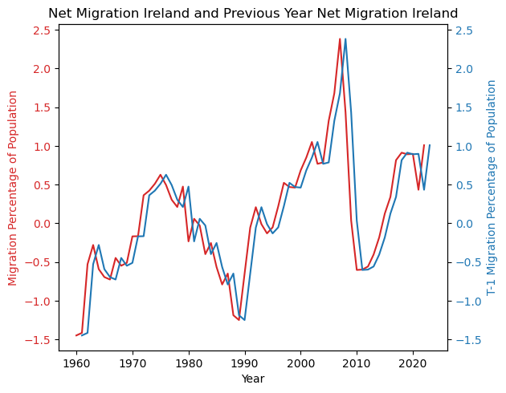

```python
# plot 'T-1 Migration Percentage of Population' and 'Migration Percentage of Population' by year
fig, ax1 = plt.subplots()

color = 'tab:red'
ax1.set_xlabel('Year')
ax1.set_ylabel('Migration Percentage of Population', color=color)
ax1.plot(Net_Migration['Year'], Net_Migration['Migration Percentage of Population'], color=color)
ax1.tick_params(axis='y', labelcolor=color)

ax2 = ax1.twinx()  # instantiate a second axes that shares the same x-axis

color = 'tab:blue'
ax2.set_ylabel('T-1 Migration Percentage of Population', color=color)  # we already handled the x-label with ax1
ax2.plot(Net_Migration['Year'], Net_Migration['T-1 Migration Percentage of Population'], color=color)
ax2.tick_params(axis='y', labelcolor=color)

fig.tight_layout()  # otherwise the right y-label is slightly clipped
plt.title('Net Migration Ireland and Previous Year Net Migration Ireland')
plt.show()
```

```python
Net_Migration.tail()
```

|  | Year | Migration Percentage of Population | T-1 Net migration 25-44 years | T-1 Enterprises_Ireland_250+ | T-1 General Surplus/Deficit (Million Euros) | T-1 Trade Volume Index Imports (Base 2010) | T-1 Housing_CPI | T-1 Trade Volume Index Exports (Base 2010) | T-1 Unemployment rate_Ireland_Total_Foreign-born | T-1 Emigrants 15-24 years | T-1 Emigrants_EU15 to EU27 | T-1 South Asia Percentage Change | T-1 Migration Percentage of Population | T-1 Crisis Indicator |
| --- | --- | --- | --- | --- | --- | --- | --- | --- | --- | --- | --- | --- | --- | --- |
| 69 | 2021.0 | 0.433127 | 16666.666667 | 666.0 | -18704.0 | 194.4 | -1.008333 | 188.6 | 7.5 | 10266.666667 | 7900.0 | 1.124469 | 0.896621 | 2 |
| 70 | 2022.0 | 1.008354 | 13066.666667 | NaN | -6565.0 | 214.5 | 5.650000 | 191.3 | 7.5 | 12733.333333 | 4400.0 | 1.029464 | 0.433127 | 1 |
| 71 | 2023.0 | NaN | 21466.666667 | NaN | 8635.0 | 275.2 | 20.483333 | 233.9 | 4.9 | 14033.333333 | 5000.0 | 0.916783 | 1.008354 | 0 |
| 72 | 2024.0 | NaN | NaN | NaN | 8328.0 | NaN | NaN | NaN | NaN | NaN | 8800.0 | NaN | NaN | 0 |
| 73 | NaN | NaN | NaN | NaN | NaN | NaN | NaN | NaN | NaN | NaN | NaN | NaN | NaN | 0 |

## Make Percentages for Variables where could be needed

```python
for index, row in Net_Migration.iterrows():
    Year = row['Year']

    # Get M1 values
    M1_current_year = row['T-1 Net migration 25-44 years']
    M1_previous_year = Net_Migration.loc[index - 1, 'T-1 Net migration 25-44 years'] if index > 0 else None
    M1_percentage_change = (M1_current_year - M1_previous_year) / M1_previous_year * 100 if M1_previous_year else None

    # Get M2 values
    M2_current_year = row['T-1 Emigrants 15-24 years']
    M2_previous_year = Net_Migration.loc[index - 1, 'T-1 Emigrants 15-24 years'] if index > 0 else None
    M2_percentage_change = (M2_current_year - M2_previous_year) / M2_previous_year * 100 if M2_previous_year else None

    # Get M3 values
    M3_current_year = row['T-1 Emigrants_EU15 to EU27']
    M3_previous_year = Net_Migration.loc[index - 1, 'T-1 Emigrants_EU15 to EU27'] if index > 0 else None
    M3_percentage_change = (M3_current_year - M3_previous_year) / M3_previous_year * 100 if M3_previous_year else None

    # Get M4 values
    M4_current_year = row['T-1 Enterprises_Ireland_250+']
    M4_previous_year = Net_Migration.loc[index - 1, 'T-1 Enterprises_Ireland_250+'] if index > 0 else None
    M4_percentage_change = (M4_current_year - M4_previous_year) / M4_previous_year * 100 if M4_previous_year else None

    # Get M4 values
    M5_current_year = row['T-1 General Surplus/Deficit (Million Euros)']
    M5_previous_year = Net_Migration.loc[index - 1, 'T-1 General Surplus/Deficit (Million Euros)'] if index > 0 else None
    M5_percentage_change = (M5_current_year - M5_previous_year) / M5_previous_year * 100 if M5_previous_year else None

    # Store to dataframe
    Net_Migration.loc[index, 'T-1 Net migration 25-44 years Percentage Change'] = M1_percentage_change
    Net_Migration.loc[index, 'T-1 Emigrants 15-24 years Percentage Change'] = M2_percentage_change
    Net_Migration.loc[index, 'T-1 Emigrants_EU15 to EU27 Percentage Change'] = M3_percentage_change
    Net_Migration.loc[index, 'T-1 Enterprises_Ireland_250+ Percentage Change'] = M4_percentage_change
    Net_Migration.loc[index, 'T-1 General Surplus/Deficit Percentage Change'] = M5_percentage_change
```

```python
Net_Migration.tail()
```

|  | Year | Migration Percentage of Population | T-1 Net migration 25-44 years | T-1 Enterprises_Ireland_250+ | T-1 General Surplus/Deficit (Million Euros) | T-1 Trade Volume Index Imports (Base 2010) | T-1 Housing_CPI | T-1 Trade Volume Index Exports (Base 2010) | T-1 Unemployment rate_Ireland_Total_Foreign-born | T-1 Emigrants 15-24 years | T-1 Emigrants_EU15 to EU27 | T-1 South Asia Percentage Change | T-1 Migration Percentage of Population | T-1 Crisis Indicator | T-1 Net migration 25-44 years Percentage Change | T-1 Emigrants 15-24 years Percentage Change | T-1 Emigrants_EU15 to EU27 Percentage Change | T-1 Enterprises_Ireland_250+ Percentage Change | T-1 General Surplus/Deficit Percentage Change |
| --- | --- | --- | --- | --- | --- | --- | --- | --- | --- | --- | --- | --- | --- | --- | --- | --- | --- | --- | --- |
| 69 | 2021.0 | 0.433127 | 16666.666667 | 666.0 | -18704.0 | 194.4 | -1.008333 | 188.6 | 7.5 | 10266.666667 | 7900.0 | 1.124469 | 0.896621 | 2 | 8.695652 | -10.465116 | 113.513514 | -9.016393 | -1203.480826 |
| 70 | 2022.0 | 1.008354 | 13066.666667 | NaN | -6565.0 | 214.5 | 5.650000 | 191.3 | 7.5 | 12733.333333 | 4400.0 | 1.029464 | 0.433127 | 1 | -21.600000 | 24.025974 | -44.303797 | NaN | -64.900556 |
| 71 | 2023.0 | NaN | 21466.666667 | NaN | 8635.0 | 275.2 | 20.483333 | 233.9 | 4.9 | 14033.333333 | 5000.0 | 0.916783 | 1.008354 | 0 | 64.285714 | 10.209424 | 13.636364 | NaN | -231.530845 |
| 72 | 2024.0 | NaN | NaN | NaN | 8328.0 | NaN | NaN | NaN | NaN | NaN | 8800.0 | NaN | NaN | 0 | NaN | NaN | 76.000000 | NaN | -3.555298 |
| 73 | NaN | NaN | NaN | NaN | NaN | NaN | NaN | NaN | NaN | NaN | NaN | NaN | NaN | 0 | NaN | NaN | NaN | NaN | NaN |

### Check Correlations again

```python
# correlation matrix
corr4 = Net_Migration.corr()

# correlation in descending order
correlations4 = pd.DataFrame(corr4['Migration Percentage of Population'].sort_values(ascending=False))

correlations4.tail(n=46)
```

|  | Migration Percentage of Population |
| --- | --- |
| Migration Percentage of Population | 1.000000 |
| T-1 Net migration 25-44 years | 0.899971 |
| T-1 Enterprises_Ireland_250+ | 0.871235 |
| T-1 Migration Percentage of Population | 0.864008 |
| T-1 General Surplus/Deficit (Million Euros) | 0.728100 |
| T-1 Enterprises_Ireland_250+ Percentage Change | 0.602427 |
| T-1 Trade Volume Index Imports (Base 2010) | 0.588912 |
| T-1 Housing_CPI | 0.555748 |
| T-1 Trade Volume Index Exports (Base 2010) | 0.551332 |
| Year | 0.517932 |
| T-1 Emigrants_EU15 to EU27 Percentage Change | 0.412311 |
| T-1 Net migration 25-44 years Percentage Change | 0.241783 |
| T-1 General Surplus/Deficit Percentage Change | 0.183022 |
| T-1 Crisis Indicator | -0.062161 |
| T-1 Emigrants 15-24 years Percentage Change | -0.165660 |
| T-1 South Asia Percentage Change | -0.456843 |
| T-1 Emigrants_EU15 to EU27 | -0.746686 |
| T-1 Emigrants 15-24 years | -0.758266 |
| T-1 Unemployment rate_Ireland_Total_Foreign-born | -0.831090 |

Better to not create percentage changes, because these would make the correlations lower

```python
Net_Migration = Net_Migration.drop(columns=['T-1 Net migration 25-44 years Percentage Change',
                                            'T-1 Emigrants 15-24 years Percentage Change',
                                            'T-1 Emigrants_EU15 to EU27 Percentage Change',
                                            'T-1 Enterprises_Ireland_250+ Percentage Change',
                                            'T-1 General Surplus/Deficit Percentage Change'])
```

## Variable for events with impact net migration

### Important Years

1972: Ireland joins eu (https://ireland.representation.ec.europa.eu/about-us/irelands-eu-membership_en)

1980-1982: early 1980s recession (https://en.wikipedia.org/wiki/Early_1980s_recession)

1987: Black Monday US (https://en.wikipedia.org/wiki/Black_Monday_(1987))

1995: Start Celtic Tiger (boom economy of ireland until 2007: https://www.investopedia.com/terms/c/celtictiger.asp, https://www.tcd.ie/Economics/staff/dmcleese/Web/mcaleese.pdf)

1997: Asian financial crisis (https://en.wikipedia.org/wiki/1997_Asian_financial_crisis)

2004: EU enlargement (https://www.consilium.europa.eu/en/infographics/2004-enlargement-facts-and-figures/)

2007-2008: economic crisis 2008-2010: Irish Banking Crisis (https://en.wikipedia.org/wiki/Post-2008_Irish_banking_crisis)

2016: brexit referendum

2020: brexit and covid

2022: War in Ukraine (https://www.nytimes.com/article/ukraine-russia-war-timeline.html)

List

- 1972 (positive)
- 1980 (negative)
- 1981 (negative)
- 1982 (negative)
- 1987 (negative)
- 1997 (positive?)
- 2004 (positive)
- 2007 (negative)
- 2008 (negative)
- 2009 (negative)
- 2010 (negative)
- 2016 (positive?)
- 2020 (negative)
- 2022 (positive)

```python
# List of years to check against
positive_impact_years = [1972, 1997, 2004, 2016, 2022]
negative_impact_years = [1980, 1981, 1982, 1987, 2007, 2008, 2009, 2010, 2020]
any_impact_years = [1972, 1980, 1981, 1982, 1987, 1997, 2004, 2007, 2008, 2009, 2010, 2016, 2020, 2022]

# Initialize new columns with 0
Net_Migration['Events_Positive_Impact'] = 0
Net_Migration['Events_Negative_Impact'] = 0
Net_Migration['Events_Impact'] = 0


# Update 'Events_Positive' column where Year matches the specified years
Net_Migration.loc[Net_Migration['Year'].isin(positive_impact_years), 'Events_Positive_Impact'] = 1

# Update 'Events_Negative_Impact' column where Year matches the specified years
Net_Migration.loc[Net_Migration['Year'].isin(negative_impact_years), 'Events_Negative_Impact'] = 1

# Update 'Events_Impact' column where Year matches the specified years
Net_Migration.loc[Net_Migration['Year'].isin(any_impact_years), 'Events_Impact'] = 1
```

```python
Net_Migration.tail(n=20)
```

|  | Year | Migration Percentage of Population | T-1 Net migration 25-44 years | T-1 Enterprises_Ireland_250+ | T-1 General Surplus/Deficit (Million Euros) | T-1 Trade Volume Index Imports (Base 2010) | T-1 Housing_CPI | T-1 Trade Volume Index Exports (Base 2010) | T-1 Unemployment rate_Ireland_Total_Foreign-born | T-1 Emigrants 15-24 years | T-1 Emigrants_EU15 to EU27 | T-1 South Asia Percentage Change | T-1 Migration Percentage of Population | T-1 Crisis Indicator | Events_Positive_Impact | Events_Negative_Impact | Events_Impact |
| --- | --- | --- | --- | --- | --- | --- | --- | --- | --- | --- | --- | --- | --- | --- | --- | --- | --- |
| 54 | 2006.0 | 1.680086 | 22766.666667 | NaN | 2675.0 | 125.7 | 10.441667 | 101.3 | 6.0 | 9533.333333 | 800.0 | 1.686406 | 1.324547 | 0 | 0 | 0 | 0 |
| 55 | 2007.0 | 2.382391 | 28666.666667 | NaN | 5132.0 | 132.4 | 15.975000 | 99.4 | 6.1 | 10600.000000 | 2300.0 | 1.597973 | 1.680086 | 0 | 0 | 1 | 1 |
| 56 | 2008.0 | 1.432217 | 29733.333333 | NaN | 528.0 | 141.8 | 20.500000 | 102.9 | 5.9 | 12133.333333 | 7700.0 | 1.504683 | 2.382391 | 1 | 0 | 1 | 1 |
| 57 | 2009.0 | 0.035278 | 9866.666667 | 525.0 | -13167.0 | 126.8 | 9.700000 | 93.2 | 6.8 | 11866.666667 | 10100.0 | 1.463047 | 1.432217 | 3 | 0 | 1 | 1 |
| 58 | 2010.0 | -0.603050 | -7400.000000 | 489.0 | -23517.0 | 108.3 | -21.808333 | 103.5 | 15.7 | 18600.000000 | 25200.0 | 1.469735 | 0.035278 | 3 | 0 | 1 | 1 |
| 59 | 2011.0 | -0.598242 | -11800.000000 | 463.0 | -53764.0 | 100.0 | 1.775000 | 100.0 | 16.9 | 17800.000000 | 14600.0 | 1.474844 | -0.603050 | 1 | 0 | 0 | 0 |
| 60 | 2012.0 | -0.558752 | -2933.333333 | 462.0 | -23320.0 | 110.4 | 9.750000 | 106.1 | 17.3 | 23000.000000 | 10400.0 | 1.466497 | -0.598242 | 1 | 0 | 0 | 0 |
| 61 | 2013.0 | -0.404428 | -8100.000000 | 478.0 | -14864.0 | 120.2 | 0.700000 | 100.6 | 17.3 | 17333.333333 | 9200.0 | 1.413066 | -0.558752 | 3 | 0 | 0 | 0 |
| 62 | 2014.0 | -0.182492 | -6266.666667 | 505.0 | -11476.0 | 123.5 | 0.641667 | 101.1 | 15.7 | 15933.333333 | 13000.0 | 1.344711 | -0.404428 | 1 | 0 | 0 | 0 |
| 63 | 2015.0 | 0.125480 | -3900.000000 | 514.0 | -7050.0 | 130.1 | 0.016667 | 103.8 | 13.5 | 14533.333333 | 8000.0 | 1.290444 | -0.182492 | 1 | 0 | 0 | 0 |
| 64 | 2016.0 | 0.340670 | 3000.000000 | 540.0 | -5355.0 | 143.6 | 1.575000 | 115.5 | 11.4 | 11500.000000 | 5900.0 | 1.226597 | 0.125480 | 1 | 1 | 0 | 1 |
| 65 | 2017.0 | 0.815412 | 9000.000000 | 582.0 | -2079.0 | 158.2 | -0.441667 | 125.6 | 9.3 | 12200.000000 | 9300.0 | 1.212443 | 0.340670 | 0 | 0 | 0 | 0 |
| 66 | 2018.0 | 0.912207 | 12000.000000 | 609.0 | -863.0 | 168.9 | 2.050000 | 135.8 | 8.2 | 9900.000000 | 8400.0 | 1.216360 | 0.815412 | 0 | 0 | 0 | 0 |
| 67 | 2019.0 | 0.891710 | 12600.000000 | 657.0 | 437.0 | 189.2 | 5.100000 | 156.2 | 7.2 | 7866.666667 | 6000.0 | 1.187652 | 0.912207 | 0 | 0 | 0 | 0 |
| 68 | 2020.0 | 0.896621 | 15333.333333 | 732.0 | 1695.0 | 192.7 | 3.766667 | 168.5 | 5.9 | 11466.666667 | 3700.0 | 1.144473 | 0.891710 | 0 | 0 | 1 | 1 |
| 69 | 2021.0 | 0.433127 | 16666.666667 | 666.0 | -18704.0 | 194.4 | -1.008333 | 188.6 | 7.5 | 10266.666667 | 7900.0 | 1.124469 | 0.896621 | 2 | 0 | 0 | 0 |
| 70 | 2022.0 | 1.008354 | 13066.666667 | NaN | -6565.0 | 214.5 | 5.650000 | 191.3 | 7.5 | 12733.333333 | 4400.0 | 1.029464 | 0.433127 | 1 | 1 | 0 | 1 |
| 71 | 2023.0 | NaN | 21466.666667 | NaN | 8635.0 | 275.2 | 20.483333 | 233.9 | 4.9 | 14033.333333 | 5000.0 | 0.916783 | 1.008354 | 0 | 0 | 0 | 0 |
| 72 | 2024.0 | NaN | NaN | NaN | 8328.0 | NaN | NaN | NaN | NaN | NaN | 8800.0 | NaN | NaN | 0 | 0 | 0 | 0 |
| 73 | NaN | NaN | NaN | NaN | NaN | NaN | NaN | NaN | NaN | NaN | NaN | NaN | NaN | 0 | 0 | 0 | 0 |

## VIF

```python
# Drop rows with missing values
X = Net_Migration.drop(columns=['Year',
                                         'Migration Percentage of Population',
                                         'Events_Positive_Impact',
                                         'Events_Negative_Impact'])
X = X.dropna()

# VIF dataframe
vif_data = pd.DataFrame()
vif_data["feature"] = X.columns

# calculating VIF for each feature
vif_data["VIF"] = [variance_inflation_factor(X.values, i)
                          for i in range(len(X.columns))]

print(vif_data)
```

```
                                             feature           VIF
0                      T-1 Net migration 25-44 years  5.545079e+03
1                       T-1 Enterprises_Ireland_250+  1.654807e+05
2        T-1 General Surplus/Deficit (Million Euros)  6.449334e+03
3         T-1 Trade Volume Index Imports (Base 2010)  1.677360e+06
4                                    T-1 Housing_CPI  1.114872e+02
5         T-1 Trade Volume Index Exports (Base 2010)  4.525367e+05
6   T-1 Unemployment rate_Ireland_Total_Foreign-born  1.925632e+04
7                          T-1 Emigrants 15-24 years  1.117605e+05
8                         T-1 Emigrants_EU15 to EU27  6.961584e+02
9                   T-1 South Asia Percentage Change  5.709281e+05
10            T-1 Migration Percentage of Population  1.104351e+04
11                              T-1 Crisis Indicator  1.745490e+01
12                                     Events_Impact  2.521177e+02
```

```python
# Drop rows with missing values
X = Net_Migration.drop(columns=['Year',
                                         'Migration Percentage of Population',
                                         'Events_Positive_Impact',
                                         'Events_Negative_Impact',
                                         'T-1 Trade Volume Index Imports (Base 2010)',
                                         'T-1 Enterprises_Ireland_250+',
                                         'T-1 Unemployment rate_Ireland_Total_Foreign-born',
                                         'T-1 South Asia Percentage Change',
                                         'T-1 Emigrants 15-24 years',
                                         'T-1 Emigrants_EU15 to EU27'
                                         ])

X = X.dropna()

# VIF dataframe
vif_data = pd.DataFrame()
vif_data["feature"] = X.columns

# calculating VIF for each feature
vif_data["VIF"] = [variance_inflation_factor(X.values, i)
                          for i in range(len(X.columns))]

print(vif_data)
```

```
                                       feature        VIF
0                T-1 Net migration 25-44 years  23.458246
1  T-1 General Surplus/Deficit (Million Euros)   2.816890
2                              T-1 Housing_CPI   2.290159
3   T-1 Trade Volume Index Exports (Base 2010)   5.410674
4       T-1 Migration Percentage of Population  17.306174
5                         T-1 Crisis Indicator   2.951010
6                                Events_Impact   2.147001
```

```python
Net_Migration.head()
```

|  | Year | Migration Percentage of Population | T-1 Net migration 25-44 years | T-1 Enterprises_Ireland_250+ | T-1 General Surplus/Deficit (Million Euros) | T-1 Trade Volume Index Imports (Base 2010) | T-1 Housing_CPI | T-1 Trade Volume Index Exports (Base 2010) | T-1 Unemployment rate_Ireland_Total_Foreign-born | T-1 Emigrants 15-24 years | T-1 Emigrants_EU15 to EU27 | T-1 South Asia Percentage Change | T-1 Migration Percentage of Population | T-1 Crisis Indicator | Events_Positive_Impact | Events_Negative_Impact | Events_Impact |
| --- | --- | --- | --- | --- | --- | --- | --- | --- | --- | --- | --- | --- | --- | --- | --- | --- | --- |
| 0 | 1952.0 | NaN | NaN | NaN | NaN | 4.6 | NaN | 1.0 | NaN | NaN | NaN | NaN | NaN | 0 | 0 | 0 | 0 |
| 1 | 1953.0 | NaN | NaN | NaN | NaN | 3.9 | NaN | 1.2 | NaN | NaN | NaN | NaN | NaN | 0 | 0 | 0 | 0 |
| 2 | 1954.0 | NaN | NaN | NaN | NaN | 4.4 | NaN | 1.3 | NaN | NaN | NaN | NaN | NaN | 0 | 0 | 0 | 0 |
| 3 | 1955.0 | NaN | NaN | NaN | NaN | 4.3 | NaN | 1.4 | NaN | NaN | NaN | NaN | NaN | 0 | 0 | 0 | 0 |
| 4 | 1956.0 | NaN | NaN | NaN | NaN | 4.8 | NaN | 1.3 | NaN | NaN | NaN | NaN | NaN | 0 | 0 | 0 | 0 |

```python
# Simple regression model predicting 'Migration_Population_Percentage'  with Net_Migration
Net_Migration_filtered = Net_Migration.drop(columns=[
                                         'Events_Positive_Impact',
                                         'Events_Negative_Impact',
                                         'T-1 Trade Volume Index Imports (Base 2010)',
                                         'T-1 Enterprises_Ireland_250+',
                                         'T-1 Unemployment rate_Ireland_Total_Foreign-born',
                                         'T-1 South Asia Percentage Change',
                                         'T-1 Emigrants 15-24 years',
                                         'T-1 Emigrants_EU15 to EU27'
                                         ])

Net_Migration_filtered = Net_Migration_filtered.dropna()

X = Net_Migration_filtered.drop(columns=['Year','Migration Percentage of Population'])

y = Net_Migration_filtered['Migration Percentage of Population']

X = sm.add_constant(X)
model = sm.OLS(y, X).fit()

model.summary()
```

OLS Regression Results

| Dep. Variable: | Migration Percentage of Population | R-squared: | 0.901 |
| --- | --- | --- | --- |
| Model: | OLS | Adj. R-squared: | 0.843 |
| Method: | Least Squares | F-statistic: | 15.60 |
| Date: | Thu, 23 May 2024 | Prob (F-statistic): | 3.76e-05 |
| Time: | 11:03:32 | Log-Likelihood: | -0.61696 |
| No. Observations: | 20 | AIC: | 17.23 |
| Df Residuals: | 12 | BIC: | 25.20 |
| Df Model: | 7 |  |  |
| Covariance Type: | nonrobust |  |  |

|  | coef | std err | t | P>\|t\| | [0.025 | 0.975] |
| --- | --- | --- | --- | --- | --- | --- |
| const | 0.8549 | 0.380 | 2.249 | 0.044 | 0.026 | 1.683 |
| T-1 Net migration 25-44 years | 5.891e-05 | 2.29e-05 | 2.569 | 0.025 | 8.96e-06 | 0.000 |
| T-1 General Surplus/Deficit (Million Euros) | 1.126e-05 | 8.21e-06 | 1.372 | 0.195 | -6.62e-06 | 2.91e-05 |
| T-1 Housing_CPI | -0.0037 | 0.013 | -0.293 | 0.774 | -0.031 | 0.024 |
| T-1 Trade Volume Index Exports (Base 2010) | -0.0033 | 0.003 | -1.129 | 0.281 | -0.010 | 0.003 |
| T-1 Migration Percentage of Population | -0.1879 | 0.301 | -0.624 | 0.544 | -0.844 | 0.468 |
| T-1 Crisis Indicator | -0.1902 | 0.089 | -2.141 | 0.054 | -0.384 | 0.003 |
| Events_Impact | 0.0685 | 0.171 | 0.401 | 0.696 | -0.304 | 0.441 |

| Omnibus: | 0.762 | Durbin-Watson: | 2.191 |
| --- | --- | --- | --- |
| Prob(Omnibus): | 0.683 | Jarque-Bera (JB): | 0.189 |
| Skew: | 0.235 | Prob(JB): | 0.910 |
| Kurtosis: | 3.076 | Cond. No. | 9.02e+04 |

Notes:  
[1] Standard Errors assume that the covariance matrix of the errors is correctly specified.  
[2] The condition number is large, 9.02e+04. This might indicate that there are  
strong multicollinearity or other numerical problems.

```python
# Simple regression model predicting 'Migration_Population_Percentage'  with Net_Migration
Net_Migration_filtered = Net_Migration.drop(columns=[
                                         'Events_Impact',
                                         'Events_Positive_Impact',
                                         'T-1 Trade Volume Index Imports (Base 2010)',
                                         'T-1 Enterprises_Ireland_250+',
                                         'T-1 Unemployment rate_Ireland_Total_Foreign-born',
                                         'T-1 South Asia Percentage Change',
                                         'T-1 Emigrants 15-24 years',
                                         'T-1 Emigrants_EU15 to EU27',
                                         'T-1 Housing_CPI',
                                         'T-1 Trade Volume Index Exports (Base 2010)',
                                         'T-1 General Surplus/Deficit (Million Euros)'
                                         ])

Net_Migration_filtered = Net_Migration_filtered.dropna()

X = Net_Migration_filtered.drop(columns=['Year','Migration Percentage of Population'])

y = Net_Migration_filtered['Migration Percentage of Population']

X = sm.add_constant(X)
model = sm.OLS(y, X).fit()

model.summary()
```

OLS Regression Results

| Dep. Variable: | Migration Percentage of Population | R-squared: | 0.865 |
| --- | --- | --- | --- |
| Model: | OLS | Adj. R-squared: | 0.830 |
| Method: | Least Squares | F-statistic: | 24.13 |
| Date: | Thu, 23 May 2024 | Prob (F-statistic): | 2.19e-06 |
| Time: | 11:03:32 | Log-Likelihood: | -3.6817 |
| No. Observations: | 20 | AIC: | 17.36 |
| Df Residuals: | 15 | BIC: | 22.34 |
| Df Model: | 4 |  |  |
| Covariance Type: | nonrobust |  |  |

|  | coef | std err | t | P>\|t\| | [0.025 | 0.975] |
| --- | --- | --- | --- | --- | --- | --- |
| const | 0.3097 | 0.156 | 1.989 | 0.065 | -0.022 | 0.641 |
| T-1 Net migration 25-44 years | 5.842e-05 | 2.23e-05 | 2.622 | 0.019 | 1.09e-05 | 0.000 |
| T-1 Migration Percentage of Population | -0.0639 | 0.361 | -0.177 | 0.862 | -0.833 | 0.705 |
| T-1 Crisis Indicator | -0.1791 | 0.084 | -2.143 | 0.049 | -0.357 | -0.001 |
| Events_Negative_Impact | -0.0385 | 0.245 | -0.157 | 0.877 | -0.561 | 0.484 |

| Omnibus: | 0.935 | Durbin-Watson: | 1.856 |
| --- | --- | --- | --- |
| Prob(Omnibus): | 0.627 | Jarque-Bera (JB): | 0.303 |
| Skew: | 0.299 | Prob(JB): | 0.859 |
| Kurtosis: | 3.080 | Cond. No. | 8.16e+04 |

Notes:  
[1] Standard Errors assume that the covariance matrix of the errors is correctly specified.  
[2] The condition number is large, 8.16e+04. This might indicate that there are  
strong multicollinearity or other numerical problems.

```python
X_train, X_test, y_train, y_test = train_test_split(X, y, test_size=0.25, random_state=42)

X_train = sm.add_constant(X_train)
model = sm.OLS(y_train, X_train).fit()

model.summary()
```

OLS Regression Results

| Dep. Variable: | Migration Percentage of Population | R-squared: | 0.868 |
| --- | --- | --- | --- |
| Model: | OLS | Adj. R-squared: | 0.816 |
| Method: | Least Squares | F-statistic: | 16.51 |
| Date: | Thu, 23 May 2024 | Prob (F-statistic): | 0.000210 |
| Time: | 11:03:32 | Log-Likelihood: | -3.6782 |
| No. Observations: | 15 | AIC: | 17.36 |
| Df Residuals: | 10 | BIC: | 20.90 |
| Df Model: | 4 |  |  |
| Covariance Type: | nonrobust |  |  |

|  | coef | std err | t | P>\|t\| | [0.025 | 0.975] |
| --- | --- | --- | --- | --- | --- | --- |
| const | 0.2899 | 0.234 | 1.239 | 0.244 | -0.231 | 0.811 |
| T-1 Net migration 25-44 years | 7.333e-05 | 3.19e-05 | 2.300 | 0.044 | 2.28e-06 | 0.000 |
| T-1 Migration Percentage of Population | -0.2759 | 0.487 | -0.566 | 0.584 | -1.362 | 0.810 |
| T-1 Crisis Indicator | -0.1603 | 0.127 | -1.261 | 0.236 | -0.444 | 0.123 |
| Events_Negative_Impact | 0.0679 | 0.361 | 0.188 | 0.855 | -0.737 | 0.872 |

| Omnibus: | 0.730 | Durbin-Watson: | 2.316 |
| --- | --- | --- | --- |
| Prob(Omnibus): | 0.694 | Jarque-Bera (JB): | 0.150 |
| Skew: | -0.245 | Prob(JB): | 0.928 |
| Kurtosis: | 3.003 | Cond. No. | 8.70e+04 |

Notes:  
[1] Standard Errors assume that the covariance matrix of the errors is correctly specified.  
[2] The condition number is large, 8.7e+04. This might indicate that there are  
strong multicollinearity or other numerical problems.

```python
y_pred = model.predict(X_test)

comparison = pd.DataFrame({'Actual': y_test, 'Predicted': y_pred})
comparison
```

|  | Actual | Predicted |
| --- | --- | --- |
| 51 | 0.768168 | 1.248746 |
| 68 | 0.896621 | 1.236208 |
| 66 | 0.912207 | 0.944885 |
| 52 | 0.786190 | 0.732613 |
| 59 | -0.598242 | -0.569414 |

```python
print('MAE:', metrics.mean_absolute_error(y_test, y_pred))
print('MSE:', metrics.mean_squared_error(y_test, y_pred))
print('RMSE:', np.sqrt(metrics.mean_squared_error(y_test, y_pred)))
```

```
MAE: 0.18704959294207996
MSE: 0.07020866231371044
RMSE: 0.26496917238371415
```

## Unemp

```python
# Simple regression model predicting 'Migration_Population_Percentage'  with Net_Migration

Net_Migration_unemp = Net_Migration[['Year','Migration Percentage of Population', 'T-1 Unemployment rate_Ireland_Total_Foreign-born']].dropna()
X = Net_Migration_unemp['T-1 Unemployment rate_Ireland_Total_Foreign-born']
y = Net_Migration_unemp['Migration Percentage of Population']

X = sm.add_constant(X)
model = sm.OLS(y, X).fit()

model.summary()
```

OLS Regression Results

| Dep. Variable: | Migration Percentage of Population | R-squared: | 0.691 |
| --- | --- | --- | --- |
| Model: | OLS | Adj. R-squared: | 0.675 |
| Method: | Least Squares | F-statistic: | 44.66 |
| Date: | Thu, 23 May 2024 | Prob (F-statistic): | 1.67e-06 |
| Time: | 11:03:32 | Log-Likelihood: | -12.400 |
| No. Observations: | 22 | AIC: | 28.80 |
| Df Residuals: | 20 | BIC: | 30.98 |
| Df Model: | 1 |  |  |
| Covariance Type: | nonrobust |  |  |

|  | coef | std err | t | P>\|t\| | [0.025 | 0.975] |
| --- | --- | --- | --- | --- | --- | --- |
| const | 1.9671 | 0.224 | 8.765 | 0.000 | 1.499 | 2.435 |
| T-1 Unemployment rate_Ireland_Total_Foreign-born | -0.1450 | 0.022 | -6.683 | 0.000 | -0.190 | -0.100 |

| Omnibus: | 8.663 | Durbin-Watson: | 1.140 |
| --- | --- | --- | --- |
| Prob(Omnibus): | 0.013 | Jarque-Bera (JB): | 7.651 |
| Skew: | 0.785 | Prob(JB): | 0.0218 |
| Kurtosis: | 5.426 | Cond. No. | 24.6 |

Notes:  
[1] Standard Errors assume that the covariance matrix of the errors is correctly specified.

```python
# X_train, X_test, y_train, y_test = train_test_split(X, y, test_size=0.25, random_state=3)

# Calculate the index for splitting
split_index = int(len(X) * 0.8)

# Split the data into training and testing sets
X_train = X[:split_index]
X_test = X[split_index:]
y_train = y[:split_index]
y_test = y[split_index:]

X_train = sm.add_constant(X_train)
model = sm.OLS(y_train, X_train).fit()

model.summary()
```

OLS Regression Results

| Dep. Variable: | Migration Percentage of Population | R-squared: | 0.702 |
| --- | --- | --- | --- |
| Model: | OLS | Adj. R-squared: | 0.682 |
| Method: | Least Squares | F-statistic: | 35.32 |
| Date: | Thu, 23 May 2024 | Prob (F-statistic): | 2.70e-05 |
| Time: | 11:03:32 | Log-Likelihood: | -11.111 |
| No. Observations: | 17 | AIC: | 26.22 |
| Df Residuals: | 15 | BIC: | 27.89 |
| Df Model: | 1 |  |  |
| Covariance Type: | nonrobust |  |  |

|  | coef | std err | t | P>\|t\| | [0.025 | 0.975] |
| --- | --- | --- | --- | --- | --- | --- |
| const | 2.0314 | 0.278 | 7.316 | 0.000 | 1.440 | 2.623 |
| T-1 Unemployment rate_Ireland_Total_Foreign-born | -0.1489 | 0.025 | -5.943 | 0.000 | -0.202 | -0.095 |

| Omnibus: | 5.237 | Durbin-Watson: | 1.121 |
| --- | --- | --- | --- |
| Prob(Omnibus): | 0.073 | Jarque-Bera (JB): | 2.740 |
| Skew: | 0.581 | Prob(JB): | 0.254 |
| Kurtosis: | 4.587 | Cond. No. | 25.8 |

Notes:  
[1] Standard Errors assume that the covariance matrix of the errors is correctly specified.

```python
y_pred = model.predict(X_test)

comparison = pd.DataFrame({'Actual': y_test, 'Predicted': y_pred})
comparison
```

|  | Actual | Predicted |
| --- | --- | --- |
| 66 | 0.912207 | 0.810739 |
| 67 | 0.891710 | 0.959603 |
| 68 | 0.896621 | 1.153126 |
| 69 | 0.433127 | 0.914944 |
| 70 | 1.008354 | 0.914944 |

```python
print('MAE:', metrics.mean_absolute_error(y_test, y_pred))
print('MSE:', metrics.mean_squared_error(y_test, y_pred))
print('RMSE:', np.sqrt(metrics.mean_squared_error(y_test, y_pred)))
```

```
MAE: 0.2002184030778646
MSE: 0.06431448311772477
RMSE: 0.2536030029745799
```

# Filter Data for Immigration

```python
migration_t1.columns
```

```
Index(['Year', 'Immigrant Percentage of Population',
       'Emigrant Percentage of Population',
       'Migration Percentage of Population', 'Population Ireland',
       'Emigrants 15-24 years', 'Immigrants 15-24 years',
       'Net migration 15-24 years', 'Emigrants 25-44 years',
       'Immigrants 25-44 years', 'Net migration 25-44 years',
       'Ireland 10Y Bond Yield', 'Inflation Consumer Prices (Annual %)',
       'GDP Growth (annual %)', 'GDP per Capita Growth (Annual %)',
       'Inflation GDP Deflator (Annual %)', 'Housing_CPI', 'Food_Drinks_CPI',
       'General_CPI', 'Participation rate_Ireland_Women_Foreign-born',
       'Participation rate_Ireland_Women_Native-born',
       'Participation rate_United Kingdom_Women_Foreign-born',
       'Participation rate_United Kingdom_Women_Native-born',
       'Unemployment rate_Ireland_Total_Foreign-born',
       'Unemployment rate_Ireland_Total_Native-born',
       'Unemployment rate_Ireland_Women_Foreign-born',
       'Unemployment rate_Ireland_Women_Native-born',
       'Unemployment rate_United Kingdom_Total_Foreign-born',
       'Unemployment rate_United Kingdom_Total_Native-born',
       'Unemployment rate_United Kingdom_Women_Foreign-born',
       'Unemployment rate_United Kingdom_Women_Native-born',
       'Avg Participation Natives outside Ireland',
       'Avg Unemployment Natives outside Ireland',
       'Avg Participation Native Women outside Ireland',
       'Avg Unemployment Native Women outside Ireland',
       'Trade Price Index Exports (Base 2010)',
       'Trade Price Index Imports (Base 2010)',
       'Trade Volume Index Exports (Base 2010)',
       'Trade Volume Index Imports (Base 2010)',
       'Direct Investment  Flows Abroad_All countries and international organisations',
       'Direct Investment  Flows Abroad_Asia (6)',
       'Direct Investment  Flows Abroad_EU28',
       'Direct Investment  Flows Abroad_United States',
       'Direct Investment  Flows in Ireland_All countries and international organisations',
       'Direct Investment  Flows in Ireland_Asia (6)',
       'Direct Investment  Flows in Ireland_EU28',
       'Direct Investment  Flows in Ireland_United States',
       'General Surplus/Deficit (Million Euros)',
       'General Expenditure (Million Euros)',
       'Net Acquisition Financial Assets (Million Euros)',
```

[output cut: 14 more lines]

```
       'Emigrants_EU15 to EU27 (accession countries joined post 2004)',
       'Emigrants_Other countries (23)', 'Emigrants_United Kingdom (1)',
       'Emigrants_United States', 'Immigrants_All countries',
       'Immigrants_EU14 excl Irl (UK & Ireland)',
       'Immigrants_EU15 to EU27 (accession countries joined post 2004)',
       'Immigrants_Other countries (23)', 'Immigrants_United Kingdom (1)',
       'Immigrants_United States', 'Net migration_All countries',
       'Net migration_EU14 excl Irl (UK & Ireland)',
       'Net migration_EU15 to EU27 (accession countries joined post 2004)',
       'Net migration_Other countries (23)',
       'Net migration_United Kingdom (1)', 'Net migration_United States',
       'Crisis Indicator', 'T-1 Migration Percentage of Population',
       'T-1 Emigrant Percentage of Population',
       'T-1 Immigrant Percentage of Population'],
      dtype='object')
```

```python
Immigration = migration_t1[['Year',
                            'Immigrant Percentage of Population',
                            'Immigrants 25-44 years',
                            'Enterprises_Ireland_250+',
                              'Trade Volume Index Imports (Base 2010)',
                              'Housing_CPI',
                              'Trade Volume Index Exports (Base 2010)',
                              'Immigrants_Other countries (23)',
                              'Emigrants_EU15 to EU27 (accession countries joined post 2004)',
                              'East Asia & Pacific Percentage Change',
                              'Emigrants 15-24 years',
                              'South Asia Percentage Change',
                              'Unemployment rate_Ireland_Total_Foreign-born',
                              'Avg Unemployment Natives outside Ireland',
                              'Direct Investment  Flows in Ireland_United States',
                              'Ireland 10Y Bond Yield',
                              'Ireland_Tax Married 100% w 2 Children',
                              'Crisis Indicator'
]]
```

```python
# rename columns Immigration
Immigration.rename(columns={
    'Immigrants 25-44 years': 'T-1  Immigrants 25-44 years',
    'Enterprises_Ireland_250+': 'T-1 Enterprises_Ireland_250+',
    'Trade Volume Index Imports (Base 2010)': 'T-1 Trade Volume Index Imports (Base 2010)',
    'Housing_CPI': 'T-1 Housing_CPI',
    'Trade Volume Index Exports (Base 2010)': 'T-1 Trade Volume Index Exports (Base 2010)',
    'Immigrants_Other countries (23)': 'T-1 Immigrants_Other countries (23)',
    'Emigrants_EU15 to EU27 (accession countries joined post 2004)': 'T-1 Emigrants_EU15 to EU27',
    'East Asia & Pacific Percentage Change': 'T-1 East Asia & Pacific Percentage Change',
    'Emigrants 15-24 years':'T-1 Emigrants 15-24 years',
    'South Asia Percentage Change':'T-1 South Asia Percentage Change',
    'Unemployment rate_Ireland_Total_Foreign-born':'T-1 Unemployment rate_Ireland_Total_Foreign-born',
    'Avg Unemployment Natives outside Ireland':'T-1 Avg Unemployment Natives outside Ireland',
    'Direct Investment  Flows in Ireland_United States':'T-1 Direct Investment Flows in Ireland_United States',
    'Ireland 10Y Bond Yield':'T-1 Ireland 10Y Bond Yield',
    'Ireland_Tax Married 100% w 2 Children':'T-1 Ireland_Tax Married 100% w 2 Children',
    'Crisis Indicator':'T-1 Crisis Indicator'

}, inplace=True)
```

```python
Immigration.columns
```

```
Index(['Year', 'Immigrant Percentage of Population',
       'T-1  Immigrants 25-44 years', 'T-1 Enterprises_Ireland_250+',
       'T-1 Trade Volume Index Imports (Base 2010)', 'T-1 Housing_CPI',
       'T-1 Trade Volume Index Exports (Base 2010)',
       'T-1 Immigrants_Other countries (23)', 'T-1 Emigrants_EU15 to EU27',
       'T-1 East Asia & Pacific Percentage Change',
       'T-1 Emigrants 15-24 years', 'T-1 South Asia Percentage Change',
       'T-1 Unemployment rate_Ireland_Total_Foreign-born',
       'T-1 Avg Unemployment Natives outside Ireland',
       'T-1 Direct Investment Flows in Ireland_United States',
       'T-1 Ireland 10Y Bond Yield',
       'T-1 Ireland_Tax Married 100% w 2 Children', 'T-1 Crisis Indicator'],
      dtype='object')
```

## Variable for events with impact Immigration

### Important Years

1972: Ireland joins eu (https://ireland.representation.ec.europa.eu/about-us/irelands-eu-membership_en)

1980-1982: early 1980s recession (https://en.wikipedia.org/wiki/Early_1980s_recession)

1987: Black Monday US (https://en.wikipedia.org/wiki/Black_Monday_(1987))

1995: Start Celtic Tiger (boom economy of ireland until 2007: https://www.investopedia.com/terms/c/celtictiger.asp, https://www.tcd.ie/Economics/staff/dmcleese/Web/mcaleese.pdf)

1997: Asian financial crisis (https://en.wikipedia.org/wiki/1997_Asian_financial_crisis)

2004: EU enlargement (https://www.consilium.europa.eu/en/infographics/2004-enlargement-facts-and-figures/)

2007-2008: economic crisis 2008-2010: Irish Banking Crisis (https://en.wikipedia.org/wiki/Post-2008_Irish_banking_crisis)

2016: brexit referendum

2020: brexit and covid

2022: War in Ukraine (https://www.nytimes.com/article/ukraine-russia-war-timeline.html)

List

- 1972 (positive)
- 1980 (negative)
- 1981 (negative)
- 1982 (negative)
- 1987 (negative)
- 1997 (positive?)
- 2004 (positive)
- 2007 (negative)
- 2008 (negative)
- 2009 (negative)
- 2010 (negative)
- 2016 (positive?)
- 2020 (negative)
- 2022 (positive)

```python
# List of years to check against
positive_impact_years = [1972, 1997, 2004, 2016, 2022]
negative_impact_years = [1980, 1981, 1982, 1987, 2007, 2008, 2009, 2010, 2020]
any_impact_years = [1972, 1980, 1981, 1982, 1987, 1997, 2004, 2007, 2008, 2009, 2010, 2016, 2020, 2022]

# Initialize new columns with 0
Immigration['Events_Positive_Impact'] = 0
Immigration['Events_Negative_Impact'] = 0
Immigration['Events_Impact'] = 0


# Update 'Events_Positive' column where Year matches the specified years
Immigration.loc[Immigration['Year'].isin(positive_impact_years), 'Events_Positive_Impact'] = 1

# Update 'Events_Negative_Impact' column where Year matches the specified years
Immigration.loc[Immigration['Year'].isin(negative_impact_years), 'Events_Negative_Impact'] = 1

# Update 'Events_Impact' column where Year matches the specified years
Immigration.loc[Immigration['Year'].isin(any_impact_years), 'Events_Impact'] = 1
```

```python
Immigration.tail(n=20)
```

|  | Year | Immigrant Percentage of Population | T-1 Immigrants 25-44 years | T-1 Enterprises_Ireland_250+ | T-1 Trade Volume Index Imports (Base 2010) | T-1 Housing_CPI | T-1 Trade Volume Index Exports (Base 2010) | T-1 Immigrants_Other countries (23) | T-1 Emigrants_EU15 to EU27 | T-1 East Asia & Pacific Percentage Change | ... | T-1 South Asia Percentage Change | T-1 Unemployment rate_Ireland_Total_Foreign-born | T-1 Avg Unemployment Natives outside Ireland | T-1 Direct Investment Flows in Ireland_United States | T-1 Ireland 10Y Bond Yield | T-1 Ireland_Tax Married 100% w 2 Children | T-1 Crisis Indicator | Events_Positive_Impact | Events_Negative_Impact | Events_Impact |
| --- | --- | --- | --- | --- | --- | --- | --- | --- | --- | --- | --- | --- | --- | --- | --- | --- | --- | --- | --- | --- | --- |
| 54 | 2006.0 | 2.522469 | 29866.666667 | NaN | 125.7 | 10.441667 | 101.3 | 19400.0 | 800.0 | 0.749595 | ... | 1.686406 | 6.0 | 6.959259 | NaN | 3.367000 | 14.683361 | 0 | 0 | 0 | 0 |
| 55 | 2007.0 | 3.434917 | 38133.333333 | NaN | 132.4 | 15.975000 | 99.4 | 23300.0 | 2300.0 | 0.745038 | ... | 1.597973 | 6.1 | 6.375000 | NaN | 3.794083 | 13.068036 | 0 | 0 | 1 | 1 |
| 56 | 2008.0 | 2.528096 | 43866.666667 | NaN | 141.8 | 20.500000 | 102.9 | 34700.0 | 7700.0 | 0.733077 | ... | 1.504683 | 5.9 | 5.548148 | NaN | 4.322500 | 11.850830 | 1 | 0 | 1 | 1 |
| 57 | 2009.0 | 1.625003 | 25833.333333 | 525.0 | 126.8 | 9.700000 | 93.2 | 20000.0 | 10100.0 | 0.728174 | ... | 1.463047 | 6.8 | 5.600000 | NaN | 4.564083 | 11.945158 | 3 | 0 | 1 | 1 |
| 58 | 2010.0 | 0.916636 | 17600.000000 | 489.0 | 108.3 | -21.808333 | 103.5 | 13600.0 | 25200.0 | 0.699826 | ... | 1.469735 | 15.7 | 7.733333 | NaN | 5.171417 | 14.488079 | 3 | 0 | 1 | 1 |
| 59 | 2011.0 | 1.163734 | 12500.000000 | 463.0 | 100.0 | 1.775000 | 100.0 | 7600.0 | 14600.0 | 0.684869 | ... | 1.474844 | 16.9 | 8.213793 | NaN | 6.067583 | 15.558923 | 1 | 0 | 0 | 0 |
| 60 | 2012.0 | 1.245779 | 17933.333333 | 462.0 | 110.4 | 9.750000 | 106.1 | 12900.0 | 10400.0 | 0.714338 | ... | 1.466497 | 17.3 | 8.070000 | NaN | 9.686333 | 16.799538 | 1 | 0 | 0 | 0 |
| 61 | 2013.0 | 1.356023 | 17600.000000 | 478.0 | 120.2 | 0.700000 | 100.6 | 14500.0 | 9200.0 | 0.798953 | ... | 1.413066 | 17.3 | 8.503333 | 3757.0 | 6.097083 | 17.384317 | 3 | 0 | 0 | 0 |
| 62 | 2014.0 | 1.427731 | 18466.666667 | 505.0 | 123.5 | 0.641667 | 101.1 | 16700.0 | 13000.0 | 0.779836 | ... | 1.344711 | 15.7 | 8.696774 | 9615.0 | 3.836000 | 17.760243 | 1 | 0 | 0 | 0 |
| 63 | 2015.0 | 1.614221 | 21066.666667 | 514.0 | 130.1 | 0.016667 | 103.8 | 18600.0 | 8000.0 | 0.749922 | ... | 1.290444 | 13.5 | 8.316667 | 6893.0 | 2.273583 | 17.986998 | 1 | 0 | 0 | 0 |
| 64 | 2016.0 | 1.730688 | 26666.666667 | 540.0 | 143.6 | 1.575000 | 115.5 | 22800.0 | 5900.0 | 0.714358 | ... | 1.226597 | 11.4 | 7.725806 | 76457.0 | 1.140500 | 17.108686 | 1 | 1 | 0 | 1 |
| 65 | 2017.0 | 1.982365 | 29800.000000 | 582.0 | 158.2 | -0.441667 | 125.6 | 22200.0 | 9300.0 | 0.706681 | ... | 1.212443 | 9.3 | 7.146667 | -55433.0 | 0.679067 | 16.661472 | 0 | 0 | 0 | 0 |
| 66 | 2018.0 | 1.972340 | 32800.000000 | 609.0 | 168.9 | 2.050000 | 135.8 | 25600.0 | 8400.0 | 0.710215 | ... | 1.216360 | 8.2 | 6.609677 | -53064.0 | 0.803833 | 16.656002 | 0 | 0 | 0 | 0 |
| 67 | 2019.0 | 1.967842 | 30366.666667 | 657.0 | 189.2 | 5.100000 | 156.2 | 29100.0 | 6000.0 | 0.612373 | ... | 1.187652 | 7.2 | 5.784375 | 74256.0 | 0.956333 | 17.050903 | 0 | 0 | 0 | 0 |
| 68 | 2020.0 | 1.917606 | 32566.666667 | 732.0 | 192.7 | 3.766667 | 168.5 | 34400.0 | 3700.0 | 0.532727 | ... | 1.144473 | 5.9 | 5.528125 | -105339.0 | 0.300333 | 17.540277 | 0 | 0 | 1 | 1 |
| 69 | 2021.0 | 1.472235 | 34000.000000 | 666.0 | 194.4 | -1.008333 | 188.6 | 36400.0 | 7900.0 | 0.428126 | ... | 1.124469 | 7.5 | 6.600000 | NaN | -0.092917 | 18.429253 | 2 | 0 | 0 | 0 |
| 70 | 2022.0 | 2.102524 | 26233.333333 | NaN | 214.5 | 5.650000 | 191.3 | 18400.0 | 4400.0 | 0.264623 | ... | 1.029464 | 7.5 | 6.078125 | -51502.0 | 0.120250 | 19.100065 | 1 | 1 | 0 | 1 |
| 71 | 2023.0 | NaN | 35833.333333 | NaN | 275.2 | 20.483333 | 233.9 | 60500.0 | 5000.0 | 0.209788 | ... | 0.916783 | 4.9 | 5.070000 | 1387.0 | 1.845417 | 19.358502 | 0 | 0 | 0 | 0 |
| 72 | 2024.0 | NaN | NaN | NaN | NaN | NaN | NaN | 75800.0 | 8800.0 | NaN | ... | NaN | NaN | NaN | NaN | 2.867667 | NaN | 0 | 0 | 0 | 0 |
| 73 | NaN | NaN | NaN | NaN | NaN | NaN | NaN | NaN | NaN | NaN | ... | NaN | NaN | NaN | NaN | 2.800750 | NaN | 0 | 0 | 0 | 0 |

20 rows × 21 columns

```python
# Drop rows with missing values
X = Immigration.drop(columns =['Year', 'Immigrant Percentage of Population',
                               'Events_Negative_Impact',
                               'Events_Positive_Impact',

                                                           'T-1 Emigrants 15-24 years',
                                                           'T-1 Trade Volume Index Exports (Base 2010)',
                                                           'T-1 East Asia & Pacific Percentage Change',
                                                           'T-1 Unemployment rate_Ireland_Total_Foreign-born',
                                                           'T-1 Immigrants_Other countries (23)',
                                                           'T-1 Emigrants_EU15 to EU27',
                                                           'T-1 South Asia Percentage Change',
                                                           'T-1 Enterprises_Ireland_250+',
                                                           'T-1 Ireland_Tax Married 100% w 2 Children',
                                                           'T-1 Trade Volume Index Imports (Base 2010)',
                                                           'T-1 Avg Unemployment Natives outside Ireland'])

X = X.dropna()

# VIF dataframe
vif_data = pd.DataFrame()
vif_data["feature"] = X.columns

# calculating VIF for each feature
vif_data["VIF"] = [variance_inflation_factor(X.values, i)
                          for i in range(len(X.columns))]

print(vif_data)
```

```
                                             feature        VIF
0                        T-1  Immigrants 25-44 years   5.384299
1                                    T-1 Housing_CPI   2.006218
2  T-1 Direct Investment Flows in Ireland_United ...   1.176269
3                         T-1 Ireland 10Y Bond Yield  16.235966
4                               T-1 Crisis Indicator  12.703867
5                                      Events_Impact   3.929016
```

## Simple OLS

```python
# Simple regression model predicting 'Migration_Population_Percentage'  with Net_Migration
Immigration_filtered = Immigration.drop(columns =['T-1 Emigrants 15-24 years',
                               'Events_Negative_Impact',
                               'Events_Positive_Impact',
                                                           'T-1 Trade Volume Index Exports (Base 2010)',
                                                           'T-1 East Asia & Pacific Percentage Change',
                                                           'T-1 Unemployment rate_Ireland_Total_Foreign-born',
                                                           'T-1 Immigrants_Other countries (23)',
                                                           'T-1 Emigrants_EU15 to EU27',
                                                           'T-1 South Asia Percentage Change',
                                                           'T-1 Enterprises_Ireland_250+',
                                                           'T-1 Ireland_Tax Married 100% w 2 Children',
                                                           'T-1 Trade Volume Index Imports (Base 2010)',
                                                           'T-1 Avg Unemployment Natives outside Ireland'])
Immigration_filtered = Immigration_filtered.dropna()

X = Immigration_filtered.drop(columns = ['Year', 'Immigrant Percentage of Population'])
y = Immigration_filtered['Immigrant Percentage of Population']

X = sm.add_constant(X)
model = sm.OLS(y, X).fit()

model.summary()
```

OLS Regression Results

| Dep. Variable: | Immigrant Percentage of Population | R-squared: | 0.980 |
| --- | --- | --- | --- |
| Model: | OLS | Adj. R-squared: | 0.918 |
| Method: | Least Squares | F-statistic: | 16.01 |
| Date: | Thu, 23 May 2024 | Prob (F-statistic): | 0.0600 |
| Time: | 11:03:33 | Log-Likelihood: | 17.165 |
| No. Observations: | 9 | AIC: | -20.33 |
| Df Residuals: | 2 | BIC: | -18.95 |
| Df Model: | 6 |  |  |
| Covariance Type: | nonrobust |  |  |

|  | coef | std err | t | P>\|t\| | [0.025 | 0.975] |
| --- | --- | --- | --- | --- | --- | --- |
| const | 1.6357 | 0.308 | 5.306 | 0.034 | 0.309 | 2.962 |
| T-1 Immigrants 25-44 years | 1.273e-05 | 1.02e-05 | 1.252 | 0.337 | -3.1e-05 | 5.65e-05 |
| T-1 Housing_CPI | 0.0277 | 0.016 | 1.756 | 0.221 | -0.040 | 0.096 |
| T-1 Direct Investment Flows in Ireland_United States | -5.594e-07 | 4.82e-07 | -1.160 | 0.366 | -2.64e-06 | 1.52e-06 |
| T-1 Ireland 10Y Bond Yield | -0.1686 | 0.044 | -3.803 | 0.063 | -0.359 | 0.022 |
| T-1 Crisis Indicator | 0.1667 | 0.079 | 2.109 | 0.169 | -0.173 | 0.507 |
| Events_Impact | -0.2215 | 0.090 | -2.455 | 0.133 | -0.610 | 0.167 |

| Omnibus: | 0.617 | Durbin-Watson: | 2.726 |
| --- | --- | --- | --- |
| Prob(Omnibus): | 0.734 | Jarque-Bera (JB): | 0.122 |
| Skew: | -0.256 | Prob(JB): | 0.941 |
| Kurtosis: | 2.749 | Cond. No. | 7.23e+05 |

Notes:  
[1] Standard Errors assume that the covariance matrix of the errors is correctly specified.  
[2] The condition number is large, 7.23e+05. This might indicate that there are  
strong multicollinearity or other numerical problems.

```python
# Simple regression model predicting 'Migration_Population_Percentage'  with Net_Migration
Immigration_filtered = Immigration.drop(columns =['T-1 Emigrants 15-24 years',
                               'Events_Negative_Impact',
                               'Events_Positive_Impact',
                                                           'T-1 Trade Volume Index Exports (Base 2010)',
                                                           'T-1 East Asia & Pacific Percentage Change',
                                                           'T-1 Unemployment rate_Ireland_Total_Foreign-born',
                                                           'T-1 Immigrants_Other countries (23)',
                                                           'T-1 Emigrants_EU15 to EU27',
                                                           'T-1 South Asia Percentage Change',
                                                           'T-1 Enterprises_Ireland_250+',
                                                           'T-1 Ireland_Tax Married 100% w 2 Children',
                                                           'T-1 Trade Volume Index Imports (Base 2010)',
                                                           'T-1 Avg Unemployment Natives outside Ireland',
                                                           'T-1 Housing_CPI',
                                                           'T-1 Direct Investment Flows in Ireland_United States',
                                                           'T-1 Ireland 10Y Bond Yield'])
Immigration_filtered = Immigration_filtered.dropna()

X = Immigration_filtered.drop(columns = ['Year', 'Immigrant Percentage of Population'])
y = Immigration_filtered['Immigrant Percentage of Population']

X = sm.add_constant(X)
model = sm.OLS(y, X).fit()

model.summary()
```

OLS Regression Results

| Dep. Variable: | Immigrant Percentage of Population | R-squared: | 0.786 |
| --- | --- | --- | --- |
| Model: | OLS | Adj. R-squared: | 0.765 |
| Method: | Least Squares | F-statistic: | 37.88 |
| Date: | Thu, 23 May 2024 | Prob (F-statistic): | 1.74e-10 |
| Time: | 11:03:33 | Log-Likelihood: | -3.5668 |
| No. Observations: | 35 | AIC: | 15.13 |
| Df Residuals: | 31 | BIC: | 21.35 |
| Df Model: | 3 |  |  |
| Covariance Type: | nonrobust |  |  |

|  | coef | std err | t | P>\|t\| | [0.025 | 0.975] |
| --- | --- | --- | --- | --- | --- | --- |
| const | 0.6710 | 0.124 | 5.424 | 0.000 | 0.419 | 0.923 |
| T-1 Immigrants 25-44 years | 4.82e-05 | 5.48e-06 | 8.804 | 0.000 | 3.7e-05 | 5.94e-05 |
| T-1 Crisis Indicator | -0.1334 | 0.057 | -2.330 | 0.026 | -0.250 | -0.017 |
| Events_Impact | 0.0927 | 0.128 | 0.723 | 0.475 | -0.169 | 0.354 |

| Omnibus: | 11.796 | Durbin-Watson: | 1.360 |
| --- | --- | --- | --- |
| Prob(Omnibus): | 0.003 | Jarque-Bera (JB): | 12.585 |
| Skew: | 1.019 | Prob(JB): | 0.00185 |
| Kurtosis: | 5.116 | Cond. No. | 6.54e+04 |

Notes:  
[1] Standard Errors assume that the covariance matrix of the errors is correctly specified.  
[2] The condition number is large, 6.54e+04. This might indicate that there are  
strong multicollinearity or other numerical problems.

```python
X_train, X_test, y_train, y_test = train_test_split(X, y, test_size=0.25, random_state=42)

X_train = sm.add_constant(X_train)
model = sm.OLS(y_train, X_train).fit()

model.summary()
```

OLS Regression Results

| Dep. Variable: | Immigrant Percentage of Population | R-squared: | 0.788 |
| --- | --- | --- | --- |
| Model: | OLS | Adj. R-squared: | 0.759 |
| Method: | Least Squares | F-statistic: | 27.26 |
| Date: | Thu, 23 May 2024 | Prob (F-statistic): | 1.35e-07 |
| Time: | 11:03:33 | Log-Likelihood: | -0.29168 |
| No. Observations: | 26 | AIC: | 8.583 |
| Df Residuals: | 22 | BIC: | 13.62 |
| Df Model: | 3 |  |  |
| Covariance Type: | nonrobust |  |  |

|  | coef | std err | t | P>\|t\| | [0.025 | 0.975] |
| --- | --- | --- | --- | --- | --- | --- |
| const | 0.6773 | 0.129 | 5.255 | 0.000 | 0.410 | 0.945 |
| T-1 Immigrants 25-44 years | 4.525e-05 | 5.55e-06 | 8.152 | 0.000 | 3.37e-05 | 5.68e-05 |
| T-1 Crisis Indicator | -0.0801 | 0.065 | -1.236 | 0.230 | -0.215 | 0.054 |
| Events_Impact | -0.0287 | 0.132 | -0.217 | 0.830 | -0.303 | 0.245 |

| Omnibus: | 4.043 | Durbin-Watson: | 2.081 |
| --- | --- | --- | --- |
| Prob(Omnibus): | 0.132 | Jarque-Bera (JB): | 2.375 |
| Skew: | 0.481 | Prob(JB): | 0.305 |
| Kurtosis: | 4.125 | Cond. No. | 5.97e+04 |

Notes:  
[1] Standard Errors assume that the covariance matrix of the errors is correctly specified.  
[2] The condition number is large, 5.97e+04. This might indicate that there are  
strong multicollinearity or other numerical problems.

```python
y_pred = model.predict(X_test)

comparison = pd.DataFrame({'Actual': y_test, 'Predicted': y_pred})
comparison
```

|  | Actual | Predicted |
| --- | --- | --- |
| 62 | 1.427731 | 1.432864 |
| 49 | 1.526029 | 1.383249 |
| 60 | 1.245779 | 1.408729 |
| 57 | 1.625003 | 1.577288 |
| 51 | 1.501306 | 1.579020 |
| 65 | 1.982365 | 2.025848 |
| 55 | 3.434917 | 2.374239 |
| 48 | 1.382328 | 1.247325 |
| 44 | 1.077660 | 1.117762 |

```python
print('MAE:', metrics.mean_absolute_error(y_test, y_pred))
print('MSE:', metrics.mean_squared_error(y_test, y_pred))
print('RMSE:', np.sqrt(metrics.mean_squared_error(y_test, y_pred)))
```

```
MAE: 0.19061777462353444
MSE: 0.13356052273112992
RMSE: 0.36545933115892654
```

# Filter Data for Emigration

```python
migration_t1.columns
```

```
Index(['Year', 'Immigrant Percentage of Population',
       'Emigrant Percentage of Population',
       'Migration Percentage of Population', 'Population Ireland',
       'Emigrants 15-24 years', 'Immigrants 15-24 years',
       'Net migration 15-24 years', 'Emigrants 25-44 years',
       'Immigrants 25-44 years', 'Net migration 25-44 years',
       'Ireland 10Y Bond Yield', 'Inflation Consumer Prices (Annual %)',
       'GDP Growth (annual %)', 'GDP per Capita Growth (Annual %)',
       'Inflation GDP Deflator (Annual %)', 'Housing_CPI', 'Food_Drinks_CPI',
       'General_CPI', 'Participation rate_Ireland_Women_Foreign-born',
       'Participation rate_Ireland_Women_Native-born',
       'Participation rate_United Kingdom_Women_Foreign-born',
       'Participation rate_United Kingdom_Women_Native-born',
       'Unemployment rate_Ireland_Total_Foreign-born',
       'Unemployment rate_Ireland_Total_Native-born',
       'Unemployment rate_Ireland_Women_Foreign-born',
       'Unemployment rate_Ireland_Women_Native-born',
       'Unemployment rate_United Kingdom_Total_Foreign-born',
       'Unemployment rate_United Kingdom_Total_Native-born',
       'Unemployment rate_United Kingdom_Women_Foreign-born',
       'Unemployment rate_United Kingdom_Women_Native-born',
       'Avg Participation Natives outside Ireland',
       'Avg Unemployment Natives outside Ireland',
       'Avg Participation Native Women outside Ireland',
       'Avg Unemployment Native Women outside Ireland',
       'Trade Price Index Exports (Base 2010)',
       'Trade Price Index Imports (Base 2010)',
       'Trade Volume Index Exports (Base 2010)',
       'Trade Volume Index Imports (Base 2010)',
       'Direct Investment  Flows Abroad_All countries and international organisations',
       'Direct Investment  Flows Abroad_Asia (6)',
       'Direct Investment  Flows Abroad_EU28',
       'Direct Investment  Flows Abroad_United States',
       'Direct Investment  Flows in Ireland_All countries and international organisations',
       'Direct Investment  Flows in Ireland_Asia (6)',
       'Direct Investment  Flows in Ireland_EU28',
       'Direct Investment  Flows in Ireland_United States',
       'General Surplus/Deficit (Million Euros)',
       'General Expenditure (Million Euros)',
       'Net Acquisition Financial Assets (Million Euros)',
```

[output cut: 14 more lines]

```
       'Emigrants_EU15 to EU27 (accession countries joined post 2004)',
       'Emigrants_Other countries (23)', 'Emigrants_United Kingdom (1)',
       'Emigrants_United States', 'Immigrants_All countries',
       'Immigrants_EU14 excl Irl (UK & Ireland)',
       'Immigrants_EU15 to EU27 (accession countries joined post 2004)',
       'Immigrants_Other countries (23)', 'Immigrants_United Kingdom (1)',
       'Immigrants_United States', 'Net migration_All countries',
       'Net migration_EU14 excl Irl (UK & Ireland)',
       'Net migration_EU15 to EU27 (accession countries joined post 2004)',
       'Net migration_Other countries (23)',
       'Net migration_United Kingdom (1)', 'Net migration_United States',
       'Crisis Indicator', 'T-1 Migration Percentage of Population',
       'T-1 Emigrant Percentage of Population',
       'T-1 Immigrant Percentage of Population'],
      dtype='object')
```

```python
Emigration = migration_t1[['Year',
                           'Emigrant Percentage of Population',
                           'T-1 Emigrant Percentage of Population',
                           'Unemployment rate_Ireland_Total_Foreign-born',
                           'Enterprises_Ireland_250+',
                           'Direct Investment  Flows in Ireland_United States',
                           'Direct Investment  Flows Abroad_EU28',
                           'General Surplus/Deficit (Million Euros)',
                           'EU in OECD_Tax Single 100% wo Child',
                           'Food_Drinks_CPI',
                           'Crisis Indicator'
]]
```

```python
# rename columns Immigration
Emigration.rename(columns={
    'Unemployment rate_Ireland_Total_Foreign-born': 'T-1 Unemployment rate_Ireland_Total_Foreign-born',
    'Enterprises_Ireland_250+': 'T-1 Enterprises_Ireland_250+',
    'Direct Investment  Flows in Ireland_United States':'T-1 Direct Investment Flows in Ireland_United States',
    'Direct Investment  Flows Abroad_EU28': 'T-1 Direct Investment Flows Abroad_EU28',
    'General Surplus/Deficit (Million Euros)': 'T-1 General Surplus/Deficit (Million Euros)',
    'EU in OECD_Tax Single 100% wo Child': 'T-1 EU in OECD_Tax Single 100% wo Child',
    'Food_Drinks_CPI':'T-1 Food_Drinks_CPI',
    'Crisis Indicator':'T-1 Crisis Indicator'

}, inplace=True)
```

```python
Emigration.columns
```

```
Index(['Year', 'Emigrant Percentage of Population',
       'T-1 Emigrant Percentage of Population',
       'T-1 Unemployment rate_Ireland_Total_Foreign-born',
       'T-1 Enterprises_Ireland_250+',
       'T-1 Direct Investment Flows in Ireland_United States',
       'T-1 Direct Investment Flows Abroad_EU28',
       'T-1 General Surplus/Deficit (Million Euros)',
       'T-1 EU in OECD_Tax Single 100% wo Child', 'T-1 Food_Drinks_CPI',
       'T-1 Crisis Indicator'],
      dtype='object')
```

## Variable for events with impact Emigration

### Important Years

1972: Ireland joins eu (https://ireland.representation.ec.europa.eu/about-us/irelands-eu-membership_en)

1980-1982: early 1980s recession (https://en.wikipedia.org/wiki/Early_1980s_recession)

1987: Black Monday US (https://en.wikipedia.org/wiki/Black_Monday_(1987))

1995: Start Celtic Tiger (boom economy of ireland until 2007: https://www.investopedia.com/terms/c/celtictiger.asp, https://www.tcd.ie/Economics/staff/dmcleese/Web/mcaleese.pdf)

1997: Asian financial crisis (https://en.wikipedia.org/wiki/1997_Asian_financial_crisis)

2004: EU enlargement (https://www.consilium.europa.eu/en/infographics/2004-enlargement-facts-and-figures/)

2007-2008: economic crisis 2008-2010: Irish Banking Crisis (https://en.wikipedia.org/wiki/Post-2008_Irish_banking_crisis)

2016: brexit referendum

2020: brexit and covid

2022: War in Ukraine (https://www.nytimes.com/article/ukraine-russia-war-timeline.html)

List

- 1972 (positive)
- 1980 (negative)
- 1981 (negative)
- 1982 (negative)
- 1987 (negative)
- 1997 (positive?)
- 2004 (positive)
- 2007 (negative)
- 2008 (negative)
- 2009 (negative)
- 2010 (negative)
- 2016 (positive?)
- 2020 (negative)
- 2022 (positive)

```python
# List of years to check against
positive_impact_years = [1972, 1997, 2004, 2016, 2022]
negative_impact_years = [1980, 1981, 1982, 1987, 2007, 2008, 2009, 2010, 2020]
any_impact_years = [1972, 1980, 1981, 1982, 1987, 1997, 2004, 2007, 2008, 2009, 2010, 2016, 2020, 2022]

# Initialize new columns with 0
Emigration['Events_Positive_Impact'] = 0
Emigration['Events_Negative_Impact'] = 0
Emigration['Events_Impact'] = 0


# Update 'Events_Positive' column where Year matches the specified years
Emigration.loc[Emigration['Year'].isin(positive_impact_years), 'Events_Positive_Impact'] = 1

# Update 'Events_Negative_Impact' column where Year matches the specified years
Emigration.loc[Emigration['Year'].isin(negative_impact_years), 'Events_Negative_Impact'] = 1

# Update 'Events_Impact' column where Year matches the specified years
Emigration.loc[Emigration['Year'].isin(any_impact_years), 'Events_Impact'] = 1
```

```python
Emigration.tail(n=20)
```

|  | Year | Emigrant Percentage of Population | T-1 Emigrant Percentage of Population | T-1 Unemployment rate_Ireland_Total_Foreign-born | T-1 Enterprises_Ireland_250+ | T-1 Direct Investment Flows in Ireland_United States | T-1 Direct Investment Flows Abroad_EU28 | T-1 General Surplus/Deficit (Million Euros) | T-1 EU in OECD_Tax Single 100% wo Child | T-1 Food_Drinks_CPI | T-1 Crisis Indicator | Events_Positive_Impact | Events_Negative_Impact | Events_Impact |
| --- | --- | --- | --- | --- | --- | --- | --- | --- | --- | --- | --- | --- | --- | --- |
| 54 | 2006.0 | 0.842383 | 0.706745 | 6.0 | NaN | NaN | NaN | 2675.0 | 17.259740 | -0.741667 | 0 | 0 | 0 | 0 |
| 55 | 2007.0 | 1.052526 | 0.842383 | 6.1 | NaN | NaN | NaN | 5132.0 | 17.241237 | 1.375000 | 0 | 0 | 1 | 1 |
| 56 | 2008.0 | 1.095880 | 1.052526 | 5.9 | NaN | NaN | NaN | 528.0 | 17.037874 | 2.833333 | 1 | 0 | 1 | 1 |
| 57 | 2009.0 | 1.587520 | 1.095880 | 6.8 | 525.0 | NaN | NaN | -13167.0 | 17.250078 | 6.566667 | 3 | 0 | 1 | 1 |
| 58 | 2010.0 | 1.517492 | 1.587520 | 15.7 | 489.0 | NaN | NaN | -23517.0 | 16.541260 | -3.483333 | 3 | 0 | 1 | 1 |
| 59 | 2011.0 | 1.759793 | 1.517492 | 16.9 | 463.0 | NaN | NaN | -53764.0 | 16.444636 | -4.458333 | 1 | 0 | 0 | 0 |
| 60 | 2012.0 | 1.804531 | 1.759793 | 17.3 | 462.0 | NaN | NaN | -23320.0 | 17.024817 | 1.150000 | 1 | 0 | 0 | 0 |
| 61 | 2013.0 | 1.758288 | 1.804531 | 17.3 | 478.0 | 3757.0 | -278.0 | -14864.0 | 17.064759 | 0.583333 | 3 | 0 | 0 | 0 |
| 62 | 2014.0 | 1.610223 | 1.758288 | 15.7 | 505.0 | 9615.0 | 21057.0 | -11476.0 | 17.267118 | 1.041667 | 1 | 0 | 0 | 0 |
| 63 | 2015.0 | 1.488742 | 1.610223 | 13.5 | 514.0 | 6893.0 | 39875.0 | -7050.0 | 17.259027 | -2.225000 | 1 | 0 | 0 | 0 |
| 64 | 2016.0 | 1.392121 | 1.488742 | 11.4 | 540.0 | 76457.0 | 66665.0 | -5355.0 | 17.285934 | -2.158333 | 1 | 1 | 0 | 1 |
| 65 | 2017.0 | 1.166954 | 1.392121 | 9.3 | 582.0 | -55433.0 | 6500.0 | -2079.0 | 17.032170 | -1.325000 | 0 | 0 | 0 | 0 |
| 66 | 2018.0 | 1.060133 | 1.166954 | 8.2 | 609.0 | -53064.0 | -45983.0 | -863.0 | 16.975826 | -2.108333 | 0 | 0 | 0 | 0 |
| 67 | 2019.0 | 1.076132 | 1.060133 | 7.2 | 657.0 | 74256.0 | -50912.0 | 437.0 | 16.879706 | -2.016667 | 0 | 0 | 0 | 0 |
| 68 | 2020.0 | 1.020985 | 1.076132 | 5.9 | 732.0 | -105339.0 | 27835.0 | 1695.0 | 17.138764 | -0.683333 | 0 | 0 | 1 | 1 |
| 69 | 2021.0 | 1.039108 | 1.020985 | 7.5 | 666.0 | NaN | -102773.0 | -18704.0 | 16.895480 | -1.383333 | 2 | 0 | 0 | 0 |
| 70 | 2022.0 | 1.094171 | 1.039108 | 7.5 | NaN | -51502.0 | 40223.0 | -6565.0 | 16.706247 | -0.225000 | 1 | 1 | 0 | 1 |
| 71 | 2023.0 | NaN | 1.094171 | 4.9 | NaN | 1387.0 | 17769.0 | 8635.0 | 16.860680 | 6.891667 | 0 | 0 | 0 | 0 |
| 72 | 2024.0 | NaN | NaN | NaN | NaN | NaN | NaN | 8328.0 | NaN | NaN | 0 | 0 | 0 | 0 |
| 73 | NaN | NaN | NaN | NaN | NaN | NaN | NaN | NaN | NaN | NaN | 0 | 0 | 0 | 0 |

## VIF Emigration

```python
# Drop rows with missing values
X = Emigration.drop(columns =['Year', 'Emigrant Percentage of Population',
                              'Events_Negative_Impact',
                              'Events_Positive_Impact',

'T-1 EU in OECD_Tax Single 100% wo Child',
'T-1 Emigrant Percentage of Population',
'T-1 General Surplus/Deficit (Million Euros)',
'T-1 Enterprises_Ireland_250+'])

X = X.dropna()

# VIF dataframe
vif_data = pd.DataFrame()
vif_data["feature"] = X.columns

# calculating VIF for each feature
vif_data["VIF"] = [variance_inflation_factor(X.values, i)
                          for i in range(len(X.columns))]

print(vif_data)
```

```
                                             feature       VIF
0   T-1 Unemployment rate_Ireland_Total_Foreign-born  3.235997
1  T-1 Direct Investment Flows in Ireland_United ...  1.163545
2            T-1 Direct Investment Flows Abroad_EU28  2.139376
3                                T-1 Food_Drinks_CPI  1.190733
4                               T-1 Crisis Indicator  3.150090
5                                      Events_Impact  2.376415
```

## Simple OLS

```python
Emigration.tail(n=20)
```

|  | Year | Emigrant Percentage of Population | T-1 Emigrant Percentage of Population | T-1 Unemployment rate_Ireland_Total_Foreign-born | T-1 Enterprises_Ireland_250+ | T-1 Direct Investment Flows in Ireland_United States | T-1 Direct Investment Flows Abroad_EU28 | T-1 General Surplus/Deficit (Million Euros) | T-1 EU in OECD_Tax Single 100% wo Child | T-1 Food_Drinks_CPI | T-1 Crisis Indicator | Events_Positive_Impact | Events_Negative_Impact | Events_Impact |
| --- | --- | --- | --- | --- | --- | --- | --- | --- | --- | --- | --- | --- | --- | --- |
| 54 | 2006.0 | 0.842383 | 0.706745 | 6.0 | NaN | NaN | NaN | 2675.0 | 17.259740 | -0.741667 | 0 | 0 | 0 | 0 |
| 55 | 2007.0 | 1.052526 | 0.842383 | 6.1 | NaN | NaN | NaN | 5132.0 | 17.241237 | 1.375000 | 0 | 0 | 1 | 1 |
| 56 | 2008.0 | 1.095880 | 1.052526 | 5.9 | NaN | NaN | NaN | 528.0 | 17.037874 | 2.833333 | 1 | 0 | 1 | 1 |
| 57 | 2009.0 | 1.587520 | 1.095880 | 6.8 | 525.0 | NaN | NaN | -13167.0 | 17.250078 | 6.566667 | 3 | 0 | 1 | 1 |
| 58 | 2010.0 | 1.517492 | 1.587520 | 15.7 | 489.0 | NaN | NaN | -23517.0 | 16.541260 | -3.483333 | 3 | 0 | 1 | 1 |
| 59 | 2011.0 | 1.759793 | 1.517492 | 16.9 | 463.0 | NaN | NaN | -53764.0 | 16.444636 | -4.458333 | 1 | 0 | 0 | 0 |
| 60 | 2012.0 | 1.804531 | 1.759793 | 17.3 | 462.0 | NaN | NaN | -23320.0 | 17.024817 | 1.150000 | 1 | 0 | 0 | 0 |
| 61 | 2013.0 | 1.758288 | 1.804531 | 17.3 | 478.0 | 3757.0 | -278.0 | -14864.0 | 17.064759 | 0.583333 | 3 | 0 | 0 | 0 |
| 62 | 2014.0 | 1.610223 | 1.758288 | 15.7 | 505.0 | 9615.0 | 21057.0 | -11476.0 | 17.267118 | 1.041667 | 1 | 0 | 0 | 0 |
| 63 | 2015.0 | 1.488742 | 1.610223 | 13.5 | 514.0 | 6893.0 | 39875.0 | -7050.0 | 17.259027 | -2.225000 | 1 | 0 | 0 | 0 |
| 64 | 2016.0 | 1.392121 | 1.488742 | 11.4 | 540.0 | 76457.0 | 66665.0 | -5355.0 | 17.285934 | -2.158333 | 1 | 1 | 0 | 1 |
| 65 | 2017.0 | 1.166954 | 1.392121 | 9.3 | 582.0 | -55433.0 | 6500.0 | -2079.0 | 17.032170 | -1.325000 | 0 | 0 | 0 | 0 |
| 66 | 2018.0 | 1.060133 | 1.166954 | 8.2 | 609.0 | -53064.0 | -45983.0 | -863.0 | 16.975826 | -2.108333 | 0 | 0 | 0 | 0 |
| 67 | 2019.0 | 1.076132 | 1.060133 | 7.2 | 657.0 | 74256.0 | -50912.0 | 437.0 | 16.879706 | -2.016667 | 0 | 0 | 0 | 0 |
| 68 | 2020.0 | 1.020985 | 1.076132 | 5.9 | 732.0 | -105339.0 | 27835.0 | 1695.0 | 17.138764 | -0.683333 | 0 | 0 | 1 | 1 |
| 69 | 2021.0 | 1.039108 | 1.020985 | 7.5 | 666.0 | NaN | -102773.0 | -18704.0 | 16.895480 | -1.383333 | 2 | 0 | 0 | 0 |
| 70 | 2022.0 | 1.094171 | 1.039108 | 7.5 | NaN | -51502.0 | 40223.0 | -6565.0 | 16.706247 | -0.225000 | 1 | 1 | 0 | 1 |
| 71 | 2023.0 | NaN | 1.094171 | 4.9 | NaN | 1387.0 | 17769.0 | 8635.0 | 16.860680 | 6.891667 | 0 | 0 | 0 | 0 |
| 72 | 2024.0 | NaN | NaN | NaN | NaN | NaN | NaN | 8328.0 | NaN | NaN | 0 | 0 | 0 | 0 |
| 73 | NaN | NaN | NaN | NaN | NaN | NaN | NaN | NaN | NaN | NaN | 0 | 0 | 0 | 0 |

```python
# Simple regression model predicting 'Migration_Population_Percentage'  with Net_Migration
Emigration_filtered = Emigration.drop(columns =['Events_Negative_Impact',
                              'Events_Positive_Impact',
                              'T-1 EU in OECD_Tax Single 100% wo Child',
'T-1 Emigrant Percentage of Population',
'T-1 General Surplus/Deficit (Million Euros)',
'T-1 Enterprises_Ireland_250+',
'T-1 Direct Investment Flows in Ireland_United States',
'T-1 Direct Investment Flows Abroad_EU28',
'T-1 Food_Drinks_CPI'])

Emigration_filtered = Emigration_filtered.dropna()

X = Emigration_filtered.drop(columns = ['Year', 'Emigrant Percentage of Population'])
y = Emigration_filtered['Emigrant Percentage of Population']

X = sm.add_constant(X)
model = sm.OLS(y, X).fit()

model.summary()
```

OLS Regression Results

| Dep. Variable: | Emigrant Percentage of Population | R-squared: | 0.811 |
| --- | --- | --- | --- |
| Model: | OLS | Adj. R-squared: | 0.779 |
| Method: | Least Squares | F-statistic: | 25.71 |
| Date: | Thu, 23 May 2024 | Prob (F-statistic): | 9.97e-07 |
| Time: | 11:03:33 | Log-Likelihood: | 8.6002 |
| No. Observations: | 22 | AIC: | -9.200 |
| Df Residuals: | 18 | BIC: | -4.836 |
| Df Model: | 3 |  |  |
| Covariance Type: | nonrobust |  |  |

|  | coef | std err | t | P>\|t\| | [0.025 | 0.975] |
| --- | --- | --- | --- | --- | --- | --- |
| const | 0.3784 | 0.103 | 3.685 | 0.002 | 0.163 | 0.594 |
| T-1 Unemployment rate_Ireland_Total_Foreign-born | 0.0791 | 0.010 | 8.300 | 0.000 | 0.059 | 0.099 |
| T-1 Crisis Indicator | -0.0031 | 0.041 | -0.075 | 0.941 | -0.089 | 0.083 |
| Events_Impact | 0.1523 | 0.085 | 1.801 | 0.088 | -0.025 | 0.330 |

| Omnibus: | 10.916 | Durbin-Watson: | 1.911 |
| --- | --- | --- | --- |
| Prob(Omnibus): | 0.004 | Jarque-Bera (JB): | 13.815 |
| Skew: | 0.761 | Prob(JB): | 0.00100 |
| Kurtosis: | 6.572 | Cond. No. | 30.8 |

Notes:  
[1] Standard Errors assume that the covariance matrix of the errors is correctly specified.

```python
Emigration_filtered
```

|  | Year | Emigrant Percentage of Population | T-1 Unemployment rate_Ireland_Total_Foreign-born | T-1 Crisis Indicator | Events_Impact |
| --- | --- | --- | --- | --- | --- |
| 49 | 2001.0 | 0.677660 | 5.7 | 0 | 0 |
| 50 | 2002.0 | 0.651077 | 4.8 | 1 | 0 |
| 51 | 2003.0 | 0.733138 | 5.0 | 2 | 0 |
| 52 | 2004.0 | 0.651064 | 6.4 | 2 | 1 |
| 53 | 2005.0 | 0.706745 | 6.1 | 2 | 0 |
| 54 | 2006.0 | 0.842383 | 6.0 | 0 | 0 |
| 55 | 2007.0 | 1.052526 | 6.1 | 0 | 1 |
| 56 | 2008.0 | 1.095880 | 5.9 | 1 | 1 |
| 57 | 2009.0 | 1.587520 | 6.8 | 3 | 1 |
| 58 | 2010.0 | 1.517492 | 15.7 | 3 | 1 |
| 59 | 2011.0 | 1.759793 | 16.9 | 1 | 0 |
| 60 | 2012.0 | 1.804531 | 17.3 | 1 | 0 |
| 61 | 2013.0 | 1.758288 | 17.3 | 3 | 0 |
| 62 | 2014.0 | 1.610223 | 15.7 | 1 | 0 |
| 63 | 2015.0 | 1.488742 | 13.5 | 1 | 0 |
| 64 | 2016.0 | 1.392121 | 11.4 | 1 | 1 |
| 65 | 2017.0 | 1.166954 | 9.3 | 0 | 0 |
| 66 | 2018.0 | 1.060133 | 8.2 | 0 | 0 |
| 67 | 2019.0 | 1.076132 | 7.2 | 0 | 0 |
| 68 | 2020.0 | 1.020985 | 5.9 | 0 | 1 |
| 69 | 2021.0 | 1.039108 | 7.5 | 2 | 0 |
| 70 | 2022.0 | 1.094171 | 7.5 | 1 | 1 |

```python
X_train, X_test, y_train, y_test = train_test_split(X, y, test_size=0.25, random_state=42)

X_train = sm.add_constant(X_train)
model = sm.OLS(y_train, X_train).fit()

model.summary()
```

OLS Regression Results

| Dep. Variable: | Emigrant Percentage of Population | R-squared: | 0.934 |
| --- | --- | --- | --- |
| Model: | OLS | Adj. R-squared: | 0.918 |
| Method: | Least Squares | F-statistic: | 56.74 |
| Date: | Thu, 23 May 2024 | Prob (F-statistic): | 2.32e-07 |
| Time: | 11:03:33 | Log-Likelihood: | 15.408 |
| No. Observations: | 16 | AIC: | -22.82 |
| Df Residuals: | 12 | BIC: | -19.73 |
| Df Model: | 3 |  |  |
| Covariance Type: | nonrobust |  |  |

|  | coef | std err | t | P>\|t\| | [0.025 | 0.975] |
| --- | --- | --- | --- | --- | --- | --- |
| const | 0.4543 | 0.076 | 5.981 | 0.000 | 0.289 | 0.620 |
| T-1 Unemployment rate_Ireland_Total_Foreign-born | 0.0834 | 0.007 | 12.487 | 0.000 | 0.069 | 0.098 |
| T-1 Crisis Indicator | -0.0821 | 0.028 | -2.913 | 0.013 | -0.143 | -0.021 |
| Events_Impact | 0.0530 | 0.058 | 0.908 | 0.381 | -0.074 | 0.180 |

| Omnibus: | 1.959 | Durbin-Watson: | 1.572 |
| --- | --- | --- | --- |
| Prob(Omnibus): | 0.376 | Jarque-Bera (JB): | 0.506 |
| Skew: | -0.341 | Prob(JB): | 0.777 |
| Kurtosis: | 3.542 | Cond. No. | 34.5 |

Notes:  
[1] Standard Errors assume that the covariance matrix of the errors is correctly specified.

```python
y_pred = model.predict(X_test)

comparison = pd.DataFrame({'Actual': y_test, 'Predicted': y_pred})
comparison
```

|  | Actual | Predicted |
| --- | --- | --- |
| 49 | 0.677660 | 0.929843 |
| 62 | 1.610223 | 1.682056 |
| 57 | 1.587520 | 0.828426 |
| 50 | 0.651077 | 0.772703 |
| 64 | 1.392121 | 1.376299 |
| 54 | 0.842383 | 0.954871 |

```python
print('MAE:', metrics.mean_absolute_error(y_test, y_pred))
print('MSE:', metrics.mean_squared_error(y_test, y_pred))
print('RMSE:', np.sqrt(metrics.mean_squared_error(y_test, y_pred)))
```

```
MAE: 0.22217428380036455
MSE: 0.11211288828989706
RMSE: 0.33483262727801344
```

# Structural Break Tests on Migration Data

## Important Years

1972: Ireland joins eu (https://ireland.representation.ec.europa.eu/about-us/irelands-eu-membership_en)

1980-1982: early 1980s recession (https://en.wikipedia.org/wiki/Early_1980s_recession)

1987: Black Monday US (https://en.wikipedia.org/wiki/Black_Monday_(1987))

1995: Start Celtic Tiger (boom economy of ireland until 2007: https://www.investopedia.com/terms/c/celtictiger.asp, https://www.tcd.ie/Economics/staff/dmcleese/Web/mcaleese.pdf)

1997: Asian financial crisis (https://en.wikipedia.org/wiki/1997_Asian_financial_crisis)

2004: EU enlargement (https://www.consilium.europa.eu/en/infographics/2004-enlargement-facts-and-figures/)

2007-2008: economic crisis 2008-2010: Irish Banking Crisis (https://en.wikipedia.org/wiki/Post-2008_Irish_banking_crisis)

2016: brexit referendum

2020: brexit and covid

2022: War in Ukraine (https://www.nytimes.com/article/ukraine-russia-war-timeline.html)

List

- 1972 (positive)
- 1980 (negative)
- 1981 (negative)
- 1982 (negative)
- 1987 (negative)
- 1997 (positive?)
- 2004 (positive)
- 2007 (negative)
- 2008 (negative)
- 2009 (negative)
- 2010 (negative)
- 2016 (positive?)
- 2020 (negative)
- 2022 (positive)

```python
migration_filtered.tail()
```

|  | Year | Immigrant Percentage of Population | Emigrant Percentage of Population | Migration Percentage of Population | Population Ireland | Emigrants 15-24 years | Immigrants 15-24 years | Net migration 15-24 years | Emigrants 25-44 years | Immigrants 25-44 years | ... | Immigrants_Other countries (23) | Immigrants_United Kingdom (1) | Immigrants_United States | Net migration_All countries | Net migration_EU14 excl Irl (UK & Ireland) | Net migration_EU15 to EU27 (accession countries joined post 2004) | Net migration_Other countries (23) | Net migration_United Kingdom (1) | Net migration_United States | Crisis Indicator |
| --- | --- | --- | --- | --- | --- | --- | --- | --- | --- | --- | --- | --- | --- | --- | --- | --- | --- | --- | --- | --- | --- |
| 69 | 2020 | 1.917606 | 1.020985 | 0.896621 | 4985382.0 | 10266.666667 | 14666.666667 | 4433.333333 | 17333.333333 | 34000.000000 | ... | 36400.0 | 17600.0 | 6000.0 | 44700.0 | 4800.0 | 1300.0 | 27700.0 | 7900.0 | 700.0 | 2 |
| 70 | 2021 | 1.472235 | 1.039108 | 0.433127 | 5033164.0 | 12733.333333 | 9133.333333 | -3566.666667 | 13200.000000 | 26233.333333 | ... | 18400.0 | 21700.0 | 5500.0 | 21800.0 | -3200.0 | 4300.0 | 5900.0 | 4100.0 | 3100.0 | 1 |
| 71 | 2022 | 2.102524 | 1.094171 | 1.008354 | 5127170.0 | 14033.333333 | 13933.333333 | -100.000000 | 14366.666667 | 35833.333333 | ... | 60500.0 | 12800.0 | 4300.0 | 51700.0 | -4700.0 | 11800.0 | 49800.0 | -600.0 | -2000.0 | 0 |
| 72 | 2023 | NaN | NaN | NaN | NaN | NaN | NaN | NaN | NaN | NaN | ... | 75800.0 | 18400.0 | 5900.0 | 77700.0 | 3800.0 | 100.0 | 64100.0 | 3800.0 | 1000.0 | 0 |
| 73 | 2024 | NaN | NaN | NaN | NaN | NaN | NaN | NaN | NaN | NaN | ... | NaN | NaN | NaN | NaN | NaN | NaN | NaN | NaN | NaN | 0 |

5 rows × 86 columns

```python
migration_indexed = migration_filtered[['Year', 'Migration Percentage of Population', 'Immigrant Percentage of Population', 'Emigrant Percentage of Population']]

# remove first 9 rows of dataframe
migration_indexed.drop(migration_indexed.index[72:74], inplace=True)
migration_indexed.drop(migration_indexed.index[:9], inplace=True)

# Convert 'Year' to datetime
migration_indexed['Year'] = pd.to_datetime(migration_indexed['Year'], format="%Y")

# Set 'Year' as the index
migration_indexed.set_index('Year', inplace=True)
```

```python
migration_indexed.head(n=10)
```

| Year | Migration Percentage of Population | Immigrant Percentage of Population | Emigrant Percentage of Population |
| --- | --- | --- | --- |
| 1960-01-01 | -1.449480 | NaN | NaN |
| 1961-01-01 | -1.416230 | NaN | NaN |
| 1962-01-01 | -0.528905 | NaN | NaN |
| 1963-01-01 | -0.280441 | NaN | NaN |
| 1964-01-01 | -0.593047 | NaN | NaN |
| 1965-01-01 | -0.695096 | NaN | NaN |
| 1966-01-01 | -0.726945 | NaN | NaN |
| 1967-01-01 | -0.447897 | NaN | NaN |
| 1968-01-01 | -0.548782 | NaN | NaN |
| 1969-01-01 | -0.511483 | NaN | NaN |

```python
from statsmodels.tsa.arima.model import ARIMA
```

```python
model = ARIMA(migration_indexed['Migration Percentage of Population'], order=(1,0,1))
model_fit = model.fit()
model_fit.summary()
```

SARIMAX Results

| Dep. Variable: | Migration Percentage of Population | No. Observations: | 63 |
| --- | --- | --- | --- |
| Model: | ARIMA(1, 0, 1) | Log Likelihood | -24.740 |
| Date: | Thu, 23 May 2024 | AIC | 57.479 |
| Time: | 11:03:33 | BIC | 66.052 |
| Sample: | 01-01-1960 | HQIC | 60.851 |
|  | - 01-01-2022 |  |  |
| Covariance Type: | opg |  |  |

|  | coef | std err | z | P>\|z\| | [0.025 | 0.975] |
| --- | --- | --- | --- | --- | --- | --- |
| const | 0.0796 | 0.254 | 0.313 | 0.754 | -0.418 | 0.578 |
| ar.L1 | 0.7914 | 0.058 | 13.593 | 0.000 | 0.677 | 0.906 |
| ma.L1 | 0.4321 | 0.097 | 4.452 | 0.000 | 0.242 | 0.622 |
| sigma2 | 0.1248 | 0.021 | 5.998 | 0.000 | 0.084 | 0.166 |

| Ljung-Box (L1) (Q): | 0.06 | Jarque-Bera (JB): | 0.97 |
| --- | --- | --- | --- |
| Prob(Q): | 0.80 | Prob(JB): | 0.62 |
| Heteroskedasticity (H): | 1.74 | Skew: | -0.22 |
| Prob(H) (two-sided): | 0.21 | Kurtosis: | 3.41 |

Warnings:  
[1] Covariance matrix calculated using the outer product of gradients (complex-step).

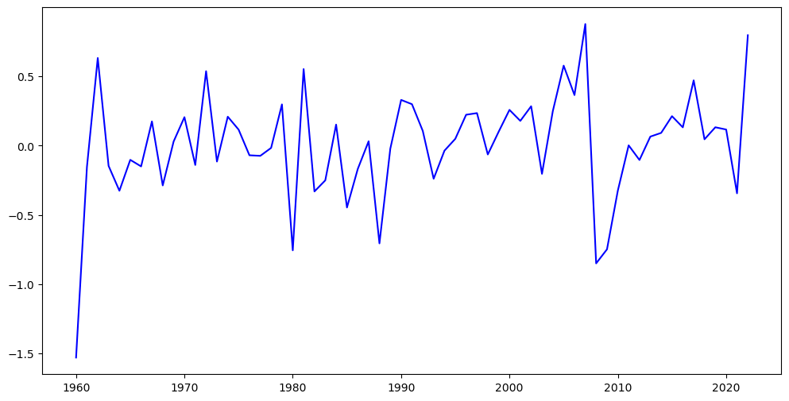

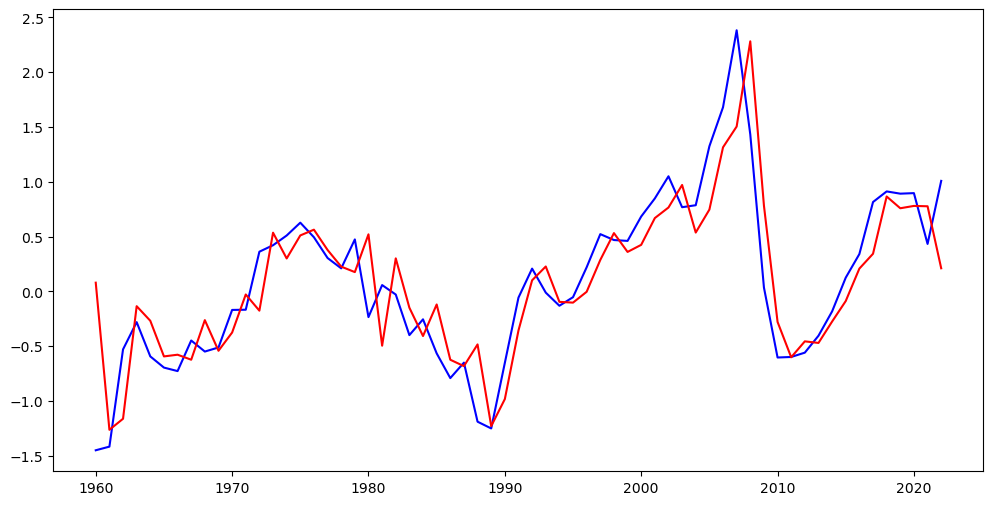

```python
# fitted values for model_fit with year in dataframe
migration_indexed['fitted_values'] = model_fit.fittedvalues
migration_indexed['residuals'] = model_fit.resid

# plot data
plt.figure(figsize=(12,6))
plt.plot(migration_indexed['residuals'], color='blue')

# plot data
plt.figure(figsize=(12,6))
plt.plot(migration_indexed['Migration Percentage of Population'], color='blue')
plt.plot(migration_indexed['fitted_values'], color='red')
```

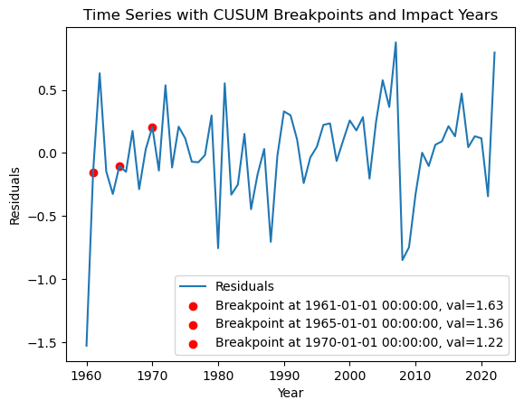

```python
import numpy as np
import statsmodels.api as sm
import matplotlib.pyplot as plt

# Perform CUSUM test on residuals
res = sm.stats.diagnostic.breaks_cusumolsresid(model_fit.resid)

# Plot the time series data
plt.plot(migration_indexed.index, migration_indexed['residuals'], label='Residuals')

# Plot markers for breakpoints detected by the test
breakpoints = [(migration_indexed.index[i], val) for i, val in res[2]]
for year, val in breakpoints:
    plt.scatter(year, migration_indexed.loc[year, 'residuals'], color='red', label=f'Breakpoint at {year}, val={val}')

# Mark specific years from any_impact_years
any_impact_years = [1972, 1980, 1981, 1982, 1987, 1997, 2004, 2007, 2008, 2009, 2010, 2016, 2020, 2022]
for year in any_impact_years:
    if year in migration_indexed.index:
        plt.scatter(year, migration_indexed.loc[year, 'residuals'], color='green', label=f'Year with Impact: {year}')

# Set plot labels and legend
plt.xlabel('Year')
plt.ylabel('Residuals')
plt.title('Time Series with CUSUM Breakpoints and Impact Years')
plt.legend()

# Show plot
plt.show()
```

[output not shown]

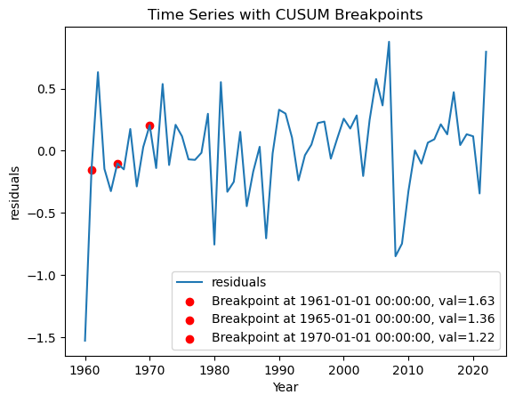

```python
# cusum test with model_fit
res = sm.stats.diagnostic.breaks_cusumolsresid(model_fit.resid)
print(res)


# Plot the time series data
plt.plot(migration_indexed.index, migration_indexed['residuals'], label='residuals')

# Plot markers for breakpoints detected by the test
breakpoints = [(migration_indexed.index[i], val) for i, val in res[2]]
for year, val in breakpoints:
    plt.scatter(year, migration_indexed.loc[year, 'residuals'], color='red', label=f'Breakpoint at {year}, val={val}')

# Set plot labels and legend
plt.xlabel('Year')
plt.ylabel('residuals')
plt.title('Time Series with CUSUM Breakpoints')
plt.legend()

# Show plot
plt.show()
```

```python
migration_ts = migration_indexed['Migration Percentage of Population']
migration_ts.head()
```

```
Year
1960-01-01   -1.449480
1961-01-01   -1.416230
1962-01-01   -0.528905
1963-01-01   -0.280441
1964-01-01   -0.593047
Name: Migration Percentage of Population, dtype: float64
```

```python
# n_breaks = 3
# y = np.array(migration_ts).tolist()
```

```python
# import ruptures as rpt
# model = rpt.Dynp(model="l1")
# model.fit(y)
# breaks = model.predict(n_bkps=n_breaks-1)
```

```python
# breaks_rpt = []
# for i in breaks:
#     breaks_rpt.append(ts.index[i-1])
# breaks_rpt = pd.to_datetime(breaks_rpt)
# breaks_rpt
```

```python
# save dataframe to csv
migration_indexed.to_csv('migration_indexed.csv')
Emigration.to_csv('Emigration.csv')
Immigration.to_csv('Immigration.csv')
Net_Migration.to_csv('Net_Migration.csv')
```